# STOCKS FUNDAMENTAL ANALYSIS

Analyzing Stock's Fundamentals!

[figure not shown]

META DATA

**1. COMPANY**: Represent name of company.

**2. NSE_CODE**: Represent code of company from National Stock Exchange.

**3. BSE_CODE**: Represent code of company from Bombay Stock Exchange.

**4. SECTOR**: Represent that in which field company works.

**5. MARKET_CAP**: Market cap or market capitalization refers to the total value of all a company's shares of stock. It is calculated by multiplying the price of a stock by its total number of outstanding shares.

**6. CURRENT_PRICE**: The current price is the most recent selling price of a stock, currency, commodity, or precious metal that is traded on an exchange and is the most reliable indicator of that security's present value.

**7. DOWN_FROM_52w_HIGH**: The 52-week high is the highest price at which a security, such as a stock, has traded during the time period that equates to one year.

**8. UP_FROM_52w_LOW**: The 52-week high is the lowest price at which a security, such as a stock, has traded during the time period that equates to one year.

**9. DEBT**: It's the sum of loan and short term debt taken by company.

**10. DIV_YIELD**: It measures the amount of cash dividends distributed to equity shareholders relative to the market value as per share

**11. BOOK_VALUE**: The book value of a stock is theoretically the amount of money that would be paid to shareholders if the company was liquidated and paid off all of its liabilities

**12. PROMOTER_HOLDING**: A promoter, as the name suggests, is an individual or an organization that helps promote the investment activity of a company. in most cases, promoters are paid in the company's stocks, or they directly invest in them. This gives the promoters a significant stake in the company. Such a stake is known as promoter's holding. Often, they also have voting rights, which gives them an influential say in the company's management.

**13. HOLDING_PLEDGED**:Pledging of shares is an arrangement in which the promoters of a company use their shares as collateral to fulfill their financial requirements.

**14. SALES**: Sales are the proceeds a company generates from selling goods or services to its customers: In accounting terms, sales comprise one component of a company's revenue figure. On an income statement, sales are typically referred to as gross sales.

**15. PROFIT**: Corporate profit is the money left over after a corporation pays all of its expenses excluding taxes.

**16. ROCE**: The term return on capital employed (ROCE) refers to a financial ratio that can be used to assess a company's profitability and capital efficiency. In other words, this ratio can help to understand how well a company is generating profits from its capital as it is put to use.

**17. ROE**: Return on equity (ROE) is the measure of a company's net income divided by its shareholders' equity. ROE is a gauge of a corporation's profitability and how efficiently it generates those profits. The higher the ROE, the better a company is at converting its equity financing into profits.

**18. PE**: Price to Earnings Ratio or Price to Earnings Multiple is the ratio of share price of a stock to its earnings per share (EPS). PE ratio is one of the most popular valuation metric of stocks. It provides indication whether a stock at its current market price is expensive or cheap.

**19. CAGR**: Compound annual growth rate (CAGR) is a metric that smoothes annual gains in revenue, returns, customers, etc., over a specified number of years as if the growth had happened steadily each year over that time period.

**20. EPS**: It's a company's net profit divided by the number of common shares it has outstanding.

**21. ASSET_TURNOVER**: The asset turnover ratio measures the efficiency of a company's assets in generating revenue or sales. It compares the dollar amount of sales (revenues) to its total assets as an annualized percentage. Thus, to calculate the asset turnover ratio, divide net sales or revenue by the average total assets.

**22. QUICK_RATIO**: The quick ratio measures a company's ability to quickly convert liquid assets into cash to pay for its short-term financial obligations

**22. DEBT_EQUITY**: The debt-to-equity ratio measures your company's total debt relative to the amount originally invested by the owners and the earnings that have been retained over time.

REPORT CONTENT

1. Import Modules
2. Stock Selection & Scraping  
   2.1 Data Required From Website
3. Scraping The Data With Selenium
4. Creating Data Frame with the Scarped Data  
   4.1Data Frame Information
5. Data Set Cleaning  
   5.1Removing Comma's From The Strings  
   5.2Changing The Data Type Of Numeric Strings in Integer or Float  
   5.3Checking for Null Values  
   5.4Replacing the Null Values
6. Exploratory Data Analysis (E.D.A.)  
   Getting Basic Necessary Details from Data Set  
   6.1Name & Number of Sectors  
   6.2Number of shares of each company  
   6.3Number of Companies in Each Sector  
   6.4Number of companies according to Market capitalization  
   6.5Company according to their sectors  
   6.6Loss making Sector & Companies Detail  
   6.7Profit making Sector & Companies Detail
7. "Telecomm-Service" SECTOR ANALYSIS  
   7.1Analyzing Debt and Market_Cap of companies  
   7.2CAGR check
8. "IT - Software" SECTOR ANALYSIS  
   8.1Analyzing Debt and Market_Cap of companies  
   8.2CAGR check
9. "Stock comparison  
   9.1Profit growth check  
   9.2Quick ratio check

# 1. Import Modules

- Used, libraries for this project selenium, pandas, matplotlib, seaborn, os

```python
from selenium import webdriver
from selenium.webdriver.chrome.service import Service
from selenium.webdriver.common.by import By
from selenium.webdriver.common.keys import Keys
import time
import pandas as pd
import matplotlib.pyplot as plt
import seaborn as sns
%matplotlib inline
import os
```

# 2. Stock Selection & Scraping

- Took list of 50 stocks for analysis

```python
stocks=['BAJFINANCE','DMART','RELIANCE','ASIANPAINT','BERGEPAINT','TATAMOTORS','TCS','Pidilite Inds.','TVS Motor',\
       'Rallis India','Nestle India','SBI Cards','HDFC Bank','Balkrishna Inds','Bharti Airtel','V-Mart Retail','Cipla',\
       'Shalimar Paints','Apollo Hospitals','AU Small Finance','L & T Infotech','Deepak Nitrite','Aarti Industries',\
       'Maruti Suzuki','P I Industries','Hind. Unilever','Muthoot Finance','MRF','CEAT','Tata Comm','Vodafone Idea',\
       'Trent','Torrent Pharma.','Sun Pharma.Inds.','Kansai Nerolac','Fortis Health.','St Bk of India','KPIT Technologi.',\
       'Fine Organic','Bajaj Auto','Meghmani Organi.','Varun Beverages','Power Fin.Corpn.','Goodyear India','M T N L',\
       'Medplus Health','Abbott India','Dr Lal Pathlabs','Mindtree','Subex']
```

## 2.1 Data Required From Website

- Creating blank list of those things or data which is required for analysis of stock

```python
COMPANY=[]
NSE_CODE=[]
BSE_CODE=[]
SECTOR=[]
MARKET_CAP=[]
CURRENT_PRICE=[]
DOWN_FROM_52w_HIGH=[]
UP_FROM_52w_LOW=[]

DEBT=[]
DIV_YIELD=[]
BOOK_VALUE=[]

PROMOTER_HOLDING=[]
HOLDING_PLEDGED=[]

SALES=[]
SALES_GROWTH_5yrs=[]
PROFIT=[]
PROFIT_GROWTH_5yrs=[]

ROCE=[]
ROCE_5yr_AVG=[]
ROE=[]
ROE_5yr_AVG=[]

PE=[]
PE_5yr_AVG=[]

CAGR_5yr=[]
CAGR_10yr=[]

EPS=[]
ASSET_TURNOVER=[]
QUICK_RATIO=[]
DEBT_EQUITY=[]
```

# 3. Scraping The Data With Selenium

- scraping the data of stock from website [screener.in](https://www.screener.in/)
- In scarping, i have used XPATH method to scrap the data.

```python
c_driver=Service('C:\devops\chromedriver')
driver = webdriver.Chrome(service=c_driver)
driver.maximize_window()
driver.get('https://www.screener.in/explore/')

time.sleep(1)

log_in=driver.find_element(By.XPATH, '/html/body/nav/div[1]/div/div[1]/div/div[3]/div[2]/a[1]')
log_in.click()

time.sleep(1)
#Log in details to get the specific Ratios & Data
email=driver.find_element(By.XPATH, '/html/body/main/div[2]/div[2]/form/div[1]/input')
email.send_keys('genesisconstructionsolution@gmail.com')
password=driver.find_element(By.XPATH, '/html/body/main/div[2]/div[2]/form/div[2]/input')
password.send_keys('GENESIS#C.E.')
password.send_keys(Keys.ENTER)


# created a loop for the stocks list to  get the data of each stock
for i in range(len(stocks)):

    stock_search=driver.find_element(By.XPATH, '/html/body/nav/div[1]/div/div[1]/div/div[3]/div[1]/div/input')
    stock_search.send_keys(stocks[i])
    time.sleep(4)
    stock_search.send_keys(Keys.ENTER)

    time.sleep(3)

# scraping COMPANY NAME of stock
    company_name=driver.find_element(By.XPATH, '/html/body/main/div[3]/div[1]/div/h1')
    c_name=company_name.text
    COMPANY.append(c_name)

# scraping NSE CODE of stock
    nse=driver.find_element(By.XPATH, '/html/body/main/div[3]/div[2]/a[3]/span')
    nse_name=nse.text.split(': ')
    NSE_CODE.append(nse_name[1])


# scraping BSE CODE of stock
    bse=driver.find_element(By.XPATH, '/html/body/main/div[3]/div[2]/a[2]/span')
    bse_name=bse.text.split(': ')
    BSE_CODE.append(bse_name[1])

# scraping SECTOR of stock
    sector=driver.find_element(By.XPATH, '/html/body/main/section[3]/div[1]/div[1]/p/a[1]').text
    SECTOR.append(sector)

# scraping MARKET CAPITALIZATION of stock
    m_cap=driver.find_element(By.XPATH, '/html/body/main/div[3]/div[3]/div[2]/ul/li[1]/span[2]/span').text
    MARKET_CAP.append(m_cap)

# scraping CURRENT PRICE of stock
    price=driver.find_element(By.XPATH, '/html[1]/body[1]/main[1]/div[3]/div[3]/div[2]/ul[1]/li[2]/span[2]/span[1]').text
    CURRENT_PRICE.append(price)

# scraping the PERCENTAGE  of stock that it is how much lower than it's 52week (one year) high
    high=driver.find_element(By.XPATH, '/html[1]/body[1]/main[1]/div[3]/div[3]/div[2]/ul[1]/li[27]/span[2]/span[1]').text
    DOWN_FROM_52w_HIGH.append(high)

# scraping the PERCENTAGE  of stock that it is how much upper than it's 52week (one year) high
    low=driver.find_element(By.XPATH, '/html[1]/body[1]/main[1]/div[3]/div[3]/div[2]/ul[1]/li[26]/span[2]/span[1]').text
    UP_FROM_52w_LOW.append(low)

# scraping the LOAN(debt)  of stock
    debt= driver.find_element(By.XPATH, '/html[1]/body[1]/main[1]/div[3]/div[3]/div[2]/ul[1]/li[11]/span[2]/span[1]').text
    DEBT.append(debt)

# scraping the PROFIT SHARING PERCENTAGE (DIV_YIELD)  of stock
    div= driver.find_element(By.XPATH, '/html[1]/body[1]/main[1]/div[3]/div[3]/div[2]/ul[1]/li[6]/span[2]/span[1]').text
    DIV_YIELD.append(div)

# scraping the PHYSICAL ASSET VALUE (BOOK_VALUE)  of stock
    book= driver.find_element(By.XPATH, '/html[1]/body[1]/main[1]/div[3]/div[3]/div[2]/ul[1]/li[5]/span[2]/span[1]').text
    BOOK_VALUE.append(book)

# scraping the PROMOTER & OWNERS PERCENTAGE (PROMOTER_HOLDING)  of stock
    holding= driver.find_element(By.XPATH, '/html[1]/body[1]/main[1]/div[3]/div[3]/div[2]/ul[1]/li[13]/span[2]/span[1]').text
    PROMOTER_HOLDING.append(holding)

# scraping the PROMOTER & OWNERS PERCENTAGE OF PLEDGED (PROMOTER_HOLDING)  of stock
    pledge= driver.find_element(By.XPATH, '/html[1]/body[1]/main[1]/div[3]/div[3]/div[2]/ul[1]/li[21]/span[2]/span[1]').text
    HOLDING_PLEDGED.append(pledge)

# scraping the SALES GROWTH PERCENTAGE OF RECENT YEAR of stock
    sale= driver.find_element(By.XPATH, '/html[1]/body[1]/main[1]/div[3]/div[3]/div[2]/ul[1]/li[17]/span[2]/span[1]').text
    SALES.append(sale)

# scraping the AVERAGE OF 5 YEAR SALES GROWTH PERCENTAGE  of stock
    sales= driver.find_element(By.XPATH, '/html[1]/body[1]/main[1]/div[3]/div[3]/div[2]/ul[1]/li[10]/span[2]/span[1]').text
    SALES_GROWTH_5yrs.append(sales)

# scraping the PROFIT GROWTH PERCENTAGE OF RECENT YEAR of stock
    profit=driver.find_element(By.XPATH, '/html[1]/body[1]/main[1]/div[3]/div[3]/div[2]/ul[1]/li[16]/span[2]/span[1]').text
    PROFIT.append(profit)
# scraping the AVERAGE OF 5 YEAR PROFIT GROWTH PERCENTAGE  of stock
    profits= driver.find_element(By.XPATH, '/html[1]/body[1]/main[1]/div[3]/div[3]/div[2]/ul[1]/li[14]/span[2]/span[1]').text
    PROFIT_GROWTH_5yrs.append(profits)

# scraping the RETURN ON CAPITAL EMPLOYED of stock
    roce= driver.find_element(By.XPATH, '/html[1]/body[1]/main[1]/div[3]/div[3]/div[2]/ul[1]/li[7]/span[2]/span[1]').text
    ROCE.append(roce)

# scraping the AVERAGE OF 5 YEAR RETURN ON CAPITAL EMPLOYED of stock
    roce_5yr= driver.find_element(By.XPATH, '/html[1]/body[1]/main[1]/div[3]/div[3]/div[2]/ul[1]/li[22]/span[2]/span[1]').text
    ROCE_5yr_AVG.append(roce_5yr)

# scraping the RETURN ON EQUITY of stock
    roe= driver.find_element(By.XPATH, '/html[1]/body[1]/main[1]/div[3]/div[3]/div[2]/ul[1]/li[8]/span[2]/span[1]').text
    ROE.append(roe)

# scraping the AVERAGE OF 5 YEAR RETURN ON EQUITY of stock
    roe_5yr= driver.find_element(By.XPATH, '/html[1]/body[1]/main[1]/div[3]/div[3]/div[2]/ul[1]/li[18]/span[2]/span[1]').text
    ROE_5yr_AVG.append(roe_5yr)

# scraping the RATIO OF PRICE TO EARNING PER SHARE of stock
    pe= driver.find_element(By.XPATH, '/html[1]/body[1]/main[1]/div[3]/div[3]/div[2]/ul[1]/li[4]/span[2]/span[1]').text
    PE.append(pe)

# scraping the AVERAGE OF 5 YEAR RATIO OF PRICE TO EARNING PER SHARE of stock
    pe_5yr= driver.find_element(By.XPATH, '/html[1]/body[1]/main[1]/div[3]/div[3]/div[2]/ul[1]/li[12]/span[2]/span[1]').text
    PE_5yr_AVG.append(pe_5yr)

# scraping the AVERAGE OF 5 YEAR OF COMPOUND ANUAL GROWTH of stock
    cagr_5=driver.find_element(By.XPATH, '/html[1]/body[1]/main[1]/div[3]/div[3]/div[2]/ul[1]/li[25]/span[2]/span[1]').text
    CAGR_5yr.append(cagr_5)

# scraping the AVERAGE OF 10 YEAR OF COMPOUND ANUAL GROWTH of stock
    cagr_10=driver.find_element(By.XPATH, '/html[1]/body[1]/main[1]/div[3]/div[3]/div[2]/ul[1]/li[24]/span[2]/span[1]').text
    CAGR_10yr.append(cagr_10)

# scraping the EARNING PER SHARE of stock
    eps= driver.find_element(By.XPATH, '/html[1]/body[1]/main[1]/div[3]/div[3]/div[2]/ul[1]/li[15]/span[2]/span[1]').text
    EPS.append(eps)

# scraping the ASSET TURNOVER of stock
    asset= driver.find_element(By.XPATH, '/html[1]/body[1]/main[1]/div[3]/div[3]/div[2]/ul[1]/li[19]/span[2]/span[1]').text
    ASSET_TURNOVER.append(asset)

# scraping the CAPABILITY OF REPAYMENT RATIO(OUICK_RATIO) of stock
    q= driver.find_element(By.XPATH, '/html[1]/body[1]/main[1]/div[3]/div[3]/div[2]/ul[1]/li[20]/span[2]/span[1]').text
    QUICK_RATIO.append(q)

# scraping the LOAN TO VALUE OF COMPANY RATIO of stock
    de= driver.find_element(By.XPATH, '/html[1]/body[1]/main[1]/div[3]/div[3]/div[2]/ul[1]/li[23]/span[2]/span[1]').text
    DEBT_EQUITY.append(de)


    nxt_stock=driver.find_element(By.XPATH, '/html[1]/body[1]/nav[1]/div[1]/div[1]/div[1]/div[1]/div[1]/a[1]/img[1]')
    nxt_stock.click()
```

# 4. Creating Data Frame With The Scarped Data

- Creating a DataFrame for the scraped data as "df" named file

```python
df=pd.DataFrame({'COMPANY':COMPANY, 'NSE_CODE':NSE_CODE, 'BSE_CODE':BSE_CODE, 'SECTOR':SECTOR,\
                 'MARKET_CAP(in Cr.)':MARKET_CAP,'CURRENT_PRICE':CURRENT_PRICE,\
                 'DOWN_FROM_52w_HIGH(in %)':DOWN_FROM_52w_HIGH,'UP_FROM_52w_LOW(in %)':UP_FROM_52w_LOW,\
                 'DEBT(in Cr.)':DEBT,'DIV_YIELD(in %)':DIV_YIELD,'BOOK_VALUE':BOOK_VALUE,\
                 'PROMOTER_HOLDING(in %)':PROMOTER_HOLDING, 'HOLDING_PLEDGED(in %)': HOLDING_PLEDGED,\
                 'SALES(in %)':SALES, 'SALES_GROWTH_5yrs(in %)':SALES_GROWTH_5yrs,'PROFIT(in %)':PROFIT,\
                 'PROFIT_GROWTH_5yrs(in %)': PROFIT_GROWTH_5yrs,'ROCE(in %)':ROCE,\
                 'ROCE_5yr_AVG(in %)':ROCE_5yr_AVG, 'ROE(in %)':ROE, 'ROE_5yr_AVG(in %)':ROE_5yr_AVG,\
                 'PE_RATIO':PE, 'PE_RATIO_5yr_AVG':PE_5yr_AVG,'CAGR_5yr(in %)':CAGR_5yr,\
                 'CAGR_10yr(in %)':CAGR_10yr,'EPS':EPS,'ASSET_TURNOVER':ASSET_TURNOVER,\
                 'QUICK_RATIO':QUICK_RATIO,'DEBT_EQUITY_RATIO':DEBT_EQUITY
             })
```

- Saving & reading the Data Frame as a CSV file

```python
df.to_csv('C:/Users/ASUS/Downloads/stock fundamental analysis project data csv.csv',index=False)
```

```python
df=pd.read_csv("C:/Users/ASUS/Downloads/stock fundamental analysis project data csv.csv")
```

```python
pd.set_option('display.max_columns',29)
df
```

|  | COMPANY | NSE_CODE | BSE_CODE | SECTOR | MARKET_CAP(in Cr.) | CURRENT_PRICE | DOWN_FROM_52w_HIGH(in %) | UP_FROM_52w_LOW(in %) | DEBT(in Cr.) | DIV_YIELD(in %) | BOOK_VALUE | PROMOTER_HOLDING(in %) | HOLDING_PLEDGED(in %) | SALES(in %) | SALES_GROWTH_5yrs(in %) | PROFIT(in %) | PROFIT_GROWTH_5yrs(in %) | ROCE(in %) | ROCE_5yr_AVG(in %) | ROE(in %) | ROE_5yr_AVG(in %) | PE_RATIO | PE_RATIO_5yr_AVG | CAGR_5yr(in %) | CAGR_10yr(in %) | EPS | ASSET_TURNOVER | QUICK_RATIO | DEBT_EQUITY_RATIO |
| --- | --- | --- | --- | --- | --- | --- | --- | --- | --- | --- | --- | --- | --- | --- | --- | --- | --- | --- | --- | --- | --- | --- | --- | --- | --- | --- | --- | --- | --- |
| 0 | Bajaj Finance Ltd | BAJFINANCE | 500034 | Finance | 422,293 | 6,975 | 13.30 | 33.60 | 183,273 | 0.29 | 794 | 55.9 | 0.00 | 30.10 | 26.00 | 99.4 | 30.90 | 10.30 | 11.00 | 17.50 | 17.70 | 42.60 | 40.70 | 31.90 | 48.50 | 164 | 0.16 | 1.26 | 3.81 |
| 1 | Avenue Supermarts Ltd | DMART | 540376 | Retail | 268,104 | 4,139 | 20.10 | 29.90 | 711 | 0.00 | 232 | 75.0 | 0.00 | 38.50 | 21.10 | 68.0 | 25.80 | 15.80 | 18.00 | 11.50 | 13.20 | 116.00 | 103.00 | 29.00 | NaN | 35.6 | 2.13 | 1.19 | 0.05 |
| 2 | Reliance Industries Ltd | RELIANCE | 500325 | Refineries | 1,740,392 | 2,572 | 9.93 | 18.00 | 316,030 | 0.31 | 1,168 | 50.6 | 0.00 | 46.40 | 18.10 | 24.2 | 14.40 | 9.42 | 10.00 | 8.16 | 9.59 | 27.10 | 17.90 | 24.10 | 20.70 | 98.1 | 0.50 | 0.63 | 0.40 |
| 3 | Asian Paints Ltd | ASIANPAINT | 500820 | Paints/Varnish | 292,090 | 3,045 | 15.20 | 19.00 | 1,866 | 0.63 | 147 | 52.6 | 10.60 | 28.20 | 14.10 | 15.6 | 9.71 | 29.70 | 33.60 | 23.20 | 25.40 | 77.60 | 59.10 | 20.90 | 22.20 | 38.2 | 1.34 | 1.04 | 0.13 |
| 4 | Berger Paints India Ltd | BERGEPAINT | 509480 | Paints/Varnish | 56,644 | 583 | 28.30 | 7.28 | 1,634 | 0.53 | 42.2 | 75.0 | 0.00 | 24.50 | 14.00 | 12.2 | 14.10 | 25.90 | 27.20 | 22.50 | 22.90 | 59.90 | 63.60 | 18.30 | 27.70 | 9.74 | 1.33 | 0.58 | 0.40 |
| 5 | Tata Motors Ltd | TATAMOTORS | 500570 | Automobile | 148,207 | 412 | 23.20 | 12.60 | 144,354 | 0.00 | 78.8 | 46.4 | 1.82 | 3.47 | 0.64 | -30,209 | NaN | 1.40 | 3.44 | -22.30 | -5.20 | NaN | -2.12 | -0.49 | 4.15 | -25.6 | 0.83 | 0.68 | 5.52 |
| 6 | Tata Consultancy Services Ltd | TCS | 532540 | IT - Software | 1,172,964 | 3,206 | 20.80 | 9.56 | 7,460 | 1.34 | 266 | 72.3 | 0.48 | 16.60 | 10.20 | 8.27 | 7.83 | 54.90 | 47.80 | 43.60 | 37.20 | 29.60 | 21.20 | 18.80 | 17.10 | 108 | 1.42 | 2.84 | 0.08 |
| 7 | Pidilite Industries Ltd | PIDILITIND | 500331 | Chemicals | 135,022 | 2,656 | 9.00 | 33.60 | 680 | 0.38 | 130 | 69.9 | 0.00 | 26.10 | 12.00 | -3.28 | 7.10 | 26.10 | 31.70 | 20.20 | 23.80 | 104.00 | 61.70 | 26.50 | 29.00 | 25.6 | 1.08 | 0.92 | 0.10 |
| 8 | TVS Motor Company Ltd | TVSMOTOR | 532343 | Automobile | 52,544 | 1,106 | 6.04 | 116.00 | 18,675 | 0.34 | 107 | 50.8 | 0.00 | 24.20 | 14.30 | 41.5 | 8.13 | 11.30 | 13.20 | 18.40 | 20.80 | 44.40 | 39.30 | 9.31 | 39.50 | 25.6 | 1.00 | 0.89 | 3.68 |
| 9 | Rallis India Ltd | RALLIS | 500355 | Agro Chemicals | 4,385 | 226 | 24.60 | 23.60 | 175 | 1.33 | 91.2 | 50.1 | 0.00 | 17.50 | 13.40 | -12.6 | 2.40 | 13.60 | 16.60 | 10.20 | 12.60 | 26.80 | 20.70 | 0.03 | 3.58 | 8.43 | 0.96 | 0.86 | 0.10 |
| 10 | Nestle India Ltd | NESTLEIND | 500790 | FMCG | 194,522 | 20,175 | 4.17 | 26.10 | 280 | 0.99 | 241 | 62.8 | 0.00 | 13.50 | 9.98 | 4.63 | 18.10 | 147.00 | 95.10 | 113.00 | 67.10 | 82.90 | 66.50 | 21.00 | 15.50 | 225 | 1.83 | 0.51 | 0.12 |
| 11 | SBI Cards & Payment Services Ltd | SBICARD | 543066 | Finance | 76,228 | 807 | 26.30 | 23.00 | 28,186 | 0.31 | 94.6 | 69.4 | 0.00 | 25.60 | 26.10 | 105 | 34.10 | 11.60 | 12.80 | 23.00 | 24.00 | 36.00 | 49.70 | NaN | NaN | 22.5 | 0.35 | 0.41 | 3.16 |
| 12 | HDFC Bank Ltd | HDFCBANK | 500180 | Banks | 849,930 | 1,525 | 11.50 | 19.90 | 1,784,970 | 1.02 | 446 | 25.6 | 0.00 | 13.90 | 13.20 | 22.0 | 20.00 | 5.83 | 6.77 | 16.60 | 16.80 | 20.40 | 24.20 | 10.80 | 16.80 | 75.2 | 0.07 | 2.66 | 7.22 |
| 13 | Balkrishna Industries Ltd | BALKRISIND | 502355 | Tyres | 36,364 | 1,881 | 25.90 | 11.80 | 2,529 | 0.85 | 359 | 58.3 | 0.00 | 37.20 | 17.40 | 2.56 | 17.00 | 23.80 | 22.00 | 21.90 | 19.50 | 25.80 | 24.90 | 14.30 | 29.90 | 73.0 | 0.87 | 0.48 | 0.36 |
| 14 | Bharti Airtel Ltd | BHARTIARTL | 532454 | Telecomm-Service | 476,676 | 826 | 1.87 | 31.30 | 217,989 | 0.36 | 131 | 55.1 | 0.00 | 19.80 | 4.07 | 125 | -3.36 | 12.00 | 8.30 | 5.86 | 2.13 | 76.70 | 36.80 | 12.70 | 12.50 | 11.4 | 0.33 | 0.45 | 2.99 |
| 15 | V-Mart Retail Ltd | VMART | 534976 | Retail | 5,594 | 2,830 | 41.60 | 17.60 | 902 | 0.03 | 430 | 46.1 | 0.00 | 76.80 | 10.70 | 4,888 | -22.40 | 5.21 | 11.40 | 1.46 | 7.58 | 92.00 | 44.20 | 15.00 | NaN | 30.8 | 0.89 | 0.28 | 1.06 |
| 16 | Cipla Ltd | CIPLA | 500087 | Pharmaceuticals | 90,575 | 1,122 | 5.31 | 32.00 | 1,068 | 0.45 | 271 | 33.6 | 0.00 | 5.50 | 8.62 | -2.62 | 23.10 | 17.50 | 13.60 | 13.20 | 11.30 | 34.90 | 27.90 | 13.00 | 11.00 | 31.8 | 0.84 | 1.97 | 0.05 |
| 17 | Shalimar Paints Ltd | SHALPAINTS | 509874 | Paints/Varnish | 1,121 | 155 | 15.80 | 64.00 | 145 | 0.00 | 51.5 | 39.9 | 0.00 | 16.30 | 0.47 | 17.9 | NaN | -7.19 | -9.53 | -18.00 | -21.40 | NaN | -10.70 | 0.54 | 5.17 | -9.00 | 0.61 | 1.36 | 0.39 |
| 18 | Apollo Hospitals Enterprise Ltd | APOLLOHOSP | 508869 | Healthcare | 61,618 | 4,285 | 27.80 | 27.50 | 3,998 | 0.27 | 417 | 29.3 | 16.40 | 16.20 | 15.10 | 7.82 | 44.80 | 17.80 | 11.80 | 16.60 | 7.94 | 73.40 | 72.40 | 33.80 | 18.00 | 58.4 | 1.19 | 1.32 | 0.67 |
| 19 | AU Small Finance Bank Ltd | AUBANK | 540611 | Banks | 41,871 | 628 | 14.30 | 35.90 | 58,575 | 0.08 | 119 | 25.6 | 0.00 | 31.30 | 35.80 | 11.4 | 6.58 | 7.19 | 8.47 | 16.60 | 17.90 | 33.30 | 34.70 | 15.80 | NaN | 19.7 | 0.10 | 2.31 | 7.84 |
| 20 | Larsen & Toubro Infotech Ltd | LTI | 540005 | IT - Software | 85,278 | 4,862 | 36.00 | 30.20 | 824 | 0.93 | 524 | 74.0 | 0.00 | 30.40 | 19.20 | 21.3 | 19.20 | 35.70 | 38.60 | 28.50 | 30.50 | 33.30 | 19.50 | 38.80 | NaN | 146 | 1.35 | 3.09 | 0.09 |
| 21 | Deepak Nitrite Ltd | DEEPAKNTR | 506401 | Chemicals | 28,361 | 2,079 | 22.70 | 23.70 | 270 | 0.34 | 268 | 45.7 | 0.00 | 28.90 | 37.80 | -13.6 | 87.00 | 44.50 | 32.80 | 37.40 | 34.20 | 30.90 | 21.50 | 57.00 | 57.00 | 67.4 | 1.70 | 2.26 | 0.07 |
| 22 | Aarti Industries Ltd | AARTIIND | 524208 | Chemicals | 25,673 | 708 | 30.30 | 16.60 | 2,594 | 0.49 | 163 | 44.2 | 0.00 | 56.70 | 17.20 | 120 | 32.90 | 22.10 | 17.60 | 27.80 | 22.20 | 19.30 | 26.50 | 29.10 | 42.40 | 36.7 | 0.81 | 0.80 | 0.44 |
| 23 | Maruti Suzuki India Ltd | MARUTI | 532500 | Automobile | 274,810 | 9,097 | 6.88 | 39.20 | 625 | 0.66 | 1,893 | 56.4 | 0.00 | 24.00 | 5.34 | 44.4 | -7.94 | 8.95 | 13.60 | 7.25 | 10.20 | 45.30 | 26.30 | 2.14 | 20.10 | 201 | 1.21 | 0.80 | 0.01 |
| 24 | P I Industries Ltd | PIIND | 523642 | Agro Chemicals | 53,018 | 3,494 | 5.52 | 49.80 | 280 | 0.17 | 436 | 46.1 | 0.00 | 23.60 | 18.40 | 29.3 | 12.90 | 17.30 | 21.20 | 14.70 | 17.50 | 51.80 | 34.70 | 33.20 | 41.90 | 67.5 | 0.72 | 2.53 | 0.04 |
| 25 | Hindustan Unilever Ltd | HINDUNILVR | 500696 | FMCG | 590,593 | 2,514 | 8.06 | 32.20 | 1,139 | 1.35 | 211 | 61.9 | 0.00 | 14.30 | 9.60 | 14.7 | 15.60 | 24.30 | 48.30 | 18.40 | 35.80 | 61.00 | 55.20 | 14.30 | 16.90 | 41.1 | 0.75 | 0.99 | 0.02 |
| 26 | Muthoot Finance Ltd | MUTHOOTFIN | 533398 | Finance | 44,377 | 1,105 | 35.80 | 16.40 | 46,770 | 1.81 | 479 | 73.4 | 0.00 | -5.33 | 14.00 | -7.43 | 27.40 | 14.20 | 15.60 | 23.60 | 25.40 | 12.10 | 12.50 | 18.00 | 17.20 | 91.2 | 0.17 | 3.29 | 2.43 |
| 27 | MRF Ltd | MRF | 500290 | Tyres | 37,087 | 87,469 | 8.89 | 39.00 | 3,118 | 0.17 | 33,566 | 27.9 | 0.00 | 17.20 | 7.57 | -53.0 | -14.90 | 7.05 | 12.60 | 4.85 | 9.76 | 65.30 | 21.80 | 5.36 | 24.00 | 1,339 | 0.85 | 0.78 | 0.22 |
| 28 | CEAT Ltd | CEATLTD | 500878 | Tyres | 6,966 | 1,722 | 3.68 | 93.50 | 2,393 | 0.17 | 809 | 47.2 | 0.00 | 20.80 | 10.20 | -89.3 | -25.50 | 6.35 | 11.60 | 2.59 | 9.28 | 182.00 | 14.80 | -0.14 | 32.10 | 5.52 | 1.08 | 0.36 | 0.73 |
| 29 | Tata Communications Ltd | TATACOMM | 500483 | Telecomm-Service | 37,453 | 1,314 | 17.40 | 53.50 | 8,840 | 1.58 | 31.8 | 58.9 | 4.96 | 3.72 | -1.04 | 34.2 | -6.74 | 21.80 | 13.20 | 282.00 | NaN | 21.10 | 16.70 | 24.60 | 24.40 | 64.4 | 0.82 | 0.61 | 9.74 |
| 30 | Vodafone Idea Ltd | IDEA | 532822 | Telecomm-Service | 27,783 | 8.65 | 48.50 | 11.60 | 248,176 | 0.00 | -23.8 | 75.0 | 0.00 | 4.92 | 1.60 | -6.46 | NaN | NaN | NaN | NaN | NaN | NaN | -0.60 | -31.80 | -17.00 | -9.20 | 0.19 | 0.24 | NaN |
| 31 | Trent Ltd | TRENT | 500251 | Retail | 52,289 | 1,471 | 6.37 | 51.60 | 4,526 | 0.12 | 67.0 | 37.0 | 0.00 | 92.00 | 19.90 | 550 | -14.40 | 9.29 | 9.60 | 1.60 | 1.76 | 176.00 | 124.00 | 36.40 | 29.00 | 10.2 | 0.67 | 0.79 | 1.90 |
| 32 | Torrent Pharmaceuticals Ltd | TORNTPHARM | 500420 | Pharmaceuticals | 56,339 | 1,665 | 4.88 | 34.00 | 4,083 | 0.24 | 180 | 71.2 | 0.00 | 8.19 | 7.91 | -5.29 | 4.12 | 18.90 | 15.50 | 18.30 | 18.10 | 47.00 | 32.60 | 22.10 | 25.80 | 23.6 | 0.63 | 0.73 | 0.67 |
| 33 | Sun Pharmaceuticals Industries Ltd | SUNPHARMA | 524715 | Pharmaceuticals | 242,489 | 1,011 | 5.63 | 37.80 | 4,366 | 0.99 | 221 | 54.5 | 4.04 | 11.80 | 4.13 | 9.17 | -0.99 | 18.40 | 12.90 | 14.00 | 10.20 | 30.60 | 43.10 | 13.90 | 11.40 | 17.1 | 0.56 | 1.74 | 0.08 |
| 34 | Kansai Nerolac Paints Ltd | KANSAINER | 500165 | Paints/Varnish | 23,896 | 443 | 29.60 | 23.80 | 314 | 0.51 | 80.9 | 75.0 | 0.00 | 20.70 | 9.46 | -22.5 | -6.75 | 11.40 | 18.10 | 8.12 | 12.80 | 58.60 | 53.00 | -2.48 | 15.70 | 7.84 | 1.13 | 1.24 | 0.07 |
| 35 | Fortis Healthcare Ltd | FORTIS | 532843 | Healthcare | 21,094 | 279 | 14.00 | 27.10 | 1,255 | 0.00 | 81.8 | 31.2 | 0.00 | 19.90 | 4.57 | 120 | -2.33 | 10.80 | 5.50 | 6.12 | 0.31 | 51.60 | 22.20 | 15.80 | 10.50 | 5.48 | 0.51 | 0.80 | 0.20 |
| 36 | State Bank of India | SBIN | 500112 | Banks | 540,608 | 606 | 2.75 | 42.50 | 4,536,570 | 1.17 | 342 | 57.5 | 0.00 | 10.40 | 4.70 | 21.7 | 160.00 | 4.44 | 4.56 | 12.20 | 5.81 | 13.10 | 12.40 | 12.70 | 10.80 | 46.1 | 0.06 | 3.06 | 14.80 |
| 37 | KPIT Technologies Ltd | KPITTECH | 542651 | IT - Software | 18,200 | 664 | 17.10 | 69.70 | 186 | 0.47 | 50.8 | 40.1 | 0.82 | 22.10 | NaN | 46.6 | NaN | 24.10 | NaN | 21.50 | NaN | 57.30 | 32.70 | NaN | NaN | 11.6 | 1.13 | 2.02 | 0.13 |
| 38 | Fine Organic Industries Ltd | FINEORG | 541557 | Chemicals | 18,207 | 5,938 | 19.00 | 81.60 | 45.0 | 0.15 | 420 | 75.0 | 0.00 | 93.70 | 19.20 | 267 | 27.20 | 38.80 | 34.10 | 30.70 | 26.80 | 34.00 | 35.50 | NaN | NaN | 175 | 1.72 | 2.61 | 0.03 |
| 39 | Bajaj Auto Ltd | BAJAJ-AUTO | 532977 | Automobile | 107,778 | 3,725 | 9.85 | 23.00 | 124 | 3.76 | 900 | 54.8 | 0.01 | 4.61 | 8.79 | -7.75 | 5.87 | 23.40 | 27.50 | 19.00 | 20.90 | 19.30 | 17.10 | 2.74 | 7.29 | 202 | 0.96 | 1.58 | 0.00 |
| 40 | Meghmani Organics Ltd | MOL | 543331 | Agro Chemicals | 2,941 | 116 | 24.20 | 43.20 | 665 | 1.21 | 63.1 | 49.4 | 0.00 | 47.20 | NaN | 59.7 | NaN | 24.10 | NaN | 22.60 | NaN | 8.51 | 8.71 | NaN | NaN | 13.6 | 1.05 | 0.71 | 0.41 |
| 41 | Varun Beverages Ltd | VBL | 540180 | FMCG | 73,987 | 1,139 | 7.62 | 109.00 | 2,371 | 0.22 | 74.1 | 63.9 | 0.04 | 50.80 | 18.00 | 115 | 72.10 | 17.40 | 14.60 | 18.60 | 15.30 | 51.40 | 55.40 | 50.30 | NaN | 22.2 | 0.98 | 0.34 | 0.49 |
| 42 | Power Finance Corporation Ltd | PFC | 532810 | Finance | 30,836 | 117 | 17.90 | 20.30 | 674,847 | 10.30 | 290 | 56.0 | 0.00 | 1.44 | 22.60 | 8.39 | 44.40 | 9.38 | 9.66 | 21.20 | 19.70 | 2.18 | 3.28 | -1.61 | 2.15 | 53.6 | 0.10 | 1.51 | 8.82 |
| 43 | Goodyear India Ltd | GOODYEAR | 500168 | Tyres | 2,481 | 1,075 | 10.80 | 37.30 | 16.7 | 1.86 | 310 | 74.0 | 0.00 | 29.60 | 10.00 | -32.2 | -4.15 | 18.00 | 19.50 | 13.20 | 13.50 | 21.80 | 15.70 | 6.03 | 12.90 | 49.3 | 1.77 | 1.08 | 0.02 |
| 44 | Mahanagar Telephone Nigam Ltd | MTNL | 500108 | Telecomm-Service | 1,373 | 21.8 | 46.60 | 30.90 | 26,820 | 0.00 | -296 | 56.9 | 0.00 | -16.80 | -17.30 | -2.26 | 2.17 | -5.08 | -11.30 | NaN | NaN | NaN | -0.48 | -0.89 | -2.19 | -40.8 | 0.09 | 0.43 | NaN |
| 45 | Medplus Health Services Ltd | MEDPLUS | 543427 | Retail | 6,904 | 579 | 56.90 | 1.52 | 815 | 0.00 | 119 | 40.4 | 50.50 | 23.10 | 13.40 | 49.4 | 25.70 | 11.40 | 12.00 | 10.40 | 9.25 | 134.00 | 126.00 | NaN | NaN | 9.00 | 1.82 | 1.28 | 0.57 |
| 46 | Abbott India Ltd | ABBOTINDIA | 500488 | Pharmaceuticals | 40,883 | 19,239 | 7.95 | 24.00 | 152 | 0.75 | 1,327 | 75.0 | 0.00 | 12.20 | 11.10 | 14.5 | 23.60 | 38.40 | 37.10 | 29.50 | 27.00 | 50.60 | 35.70 | 33.60 | 29.40 | 381 | 1.22 | 2.63 | 0.05 |
| 47 | Dr Lal Pathlabs Ltd | LALPATHLAB | 539524 | Healthcare | 19,670 | 2,360 | 40.20 | 30.70 | 285 | 0.51 | 186 | 55.0 | 0.00 | 1.53 | 18.00 | -38.6 | 17.40 | 29.40 | 32.40 | 25.10 | 24.00 | 79.30 | 51.70 | 22.60 | NaN | 29.8 | 1.04 | 1.73 | 0.18 |
| 48 | Mindtree Ltd | MINDTREE | 532819 | IT - Software | 57,401 | 3,480 | 31.20 | 31.40 | 613 | 1.06 | 344 | 61.0 | 0.00 | 35.00 | 15.00 | 36.4 | 31.60 | 41.50 | 33.40 | 33.80 | 26.90 | 30.40 | 21.60 | 47.80 | 35.00 | 115 | 1.45 | 2.96 | 0.11 |
| 49 | Subex Ltd | SUBEXLTD | 532348 | IT - Software | 1,725 | 30.6 | 50.10 | 64.50 | 14.7 | 0.00 | 10.1 | 0.0 | 0.00 | -7.65 | -1.37 | -73.2 | -19.90 | 6.18 | 8.34 | 3.68 | 5.34 | 132.00 | 20.80 | 28.30 | 7.80 | 0.23 | 0.46 | 3.75 | 0.03 |

## 4.1 Data Frame Information

```python
df.info()
```

```
<class 'pandas.core.frame.DataFrame'>
RangeIndex: 50 entries, 0 to 49
Data columns (total 29 columns):
 #   Column                    Non-Null Count  Dtype
---  ------                    --------------  -----
 0   COMPANY                   50 non-null     object
 1   NSE_CODE                  50 non-null     object
 2   BSE_CODE                  50 non-null     int64
 3   SECTOR                    50 non-null     object
 4   MARKET_CAP(in Cr.)        50 non-null     object
 5   CURRENT_PRICE             50 non-null     object
 6   DOWN_FROM_52w_HIGH(in %)  50 non-null     float64
 7   UP_FROM_52w_LOW(in %)     50 non-null     float64
 8   DEBT(in Cr.)              50 non-null     object
 9   DIV_YIELD(in %)           50 non-null     float64
```

[output cut: 21 more lines]

# 5. Data Set Cleaning

need to change the numeric value as a integer or float

## 5.1 Removing Comma's From The Strings

```python
# Replacing the comma with nothing in the data set to make the values clean
for col in df.columns:
    if df[col].dtype==object:
        df[col]=df[col].str.replace(',','')
```

```python
df.head(2)
#checking that the above cleaing is done or not
```

|  | COMPANY | NSE_CODE | BSE_CODE | SECTOR | MARKET_CAP(in Cr.) | CURRENT_PRICE | DOWN_FROM_52w_HIGH(in %) | UP_FROM_52w_LOW(in %) | DEBT(in Cr.) | DIV_YIELD(in %) | BOOK_VALUE | PROMOTER_HOLDING(in %) | HOLDING_PLEDGED(in %) | SALES(in %) | SALES_GROWTH_5yrs(in %) | PROFIT(in %) | PROFIT_GROWTH_5yrs(in %) | ROCE(in %) | ROCE_5yr_AVG(in %) | ROE(in %) | ROE_5yr_AVG(in %) | PE_RATIO | PE_RATIO_5yr_AVG | CAGR_5yr(in %) | CAGR_10yr(in %) | EPS | ASSET_TURNOVER | QUICK_RATIO | DEBT_EQUITY_RATIO |
| --- | --- | --- | --- | --- | --- | --- | --- | --- | --- | --- | --- | --- | --- | --- | --- | --- | --- | --- | --- | --- | --- | --- | --- | --- | --- | --- | --- | --- | --- |
| 0 | Bajaj Finance Ltd | BAJFINANCE | 500034 | Finance | 422293 | 6975 | 13.3 | 33.6 | 183273 | 0.29 | 794 | 55.9 | 0.0 | 30.1 | 26.0 | 99.4 | 30.9 | 10.3 | 11.0 | 17.5 | 17.7 | 42.6 | 40.7 | 31.9 | 48.5 | 164 | 0.16 | 1.26 | 3.81 |
| 1 | Avenue Supermarts Ltd | DMART | 540376 | Retail | 268104 | 4139 | 20.1 | 29.9 | 711 | 0.00 | 232 | 75.0 | 0.0 | 38.5 | 21.1 | 68.0 | 25.8 | 15.8 | 18.0 | 11.5 | 13.2 | 116.0 | 103.0 | 29.0 | NaN | 35.6 | 2.13 | 1.19 | 0.05 |

## 5.2 Changing The Data Type Of Numeric Strings In Integer Or Float

```python
for col in df.columns:
    df[col]=pd.to_numeric(df[col],errors='ignore')
```

```python
df.info()
```

```
<class 'pandas.core.frame.DataFrame'>
RangeIndex: 50 entries, 0 to 49
Data columns (total 29 columns):
 #   Column                    Non-Null Count  Dtype
---  ------                    --------------  -----
 0   COMPANY                   50 non-null     object
 1   NSE_CODE                  50 non-null     object
 2   BSE_CODE                  50 non-null     int64
 3   SECTOR                    50 non-null     object
 4   MARKET_CAP(in Cr.)        50 non-null     int64
 5   CURRENT_PRICE             50 non-null     float64
 6   DOWN_FROM_52w_HIGH(in %)  50 non-null     float64
 7   UP_FROM_52w_LOW(in %)     50 non-null     float64
 8   DEBT(in Cr.)              50 non-null     float64
 9   DIV_YIELD(in %)           50 non-null     float64
```

[output cut: 21 more lines]

## 5.3 Checking For Null Values

```python
df.isnull().sum()
```

```
COMPANY                      0
NSE_CODE                     0
BSE_CODE                     0
SECTOR                       0
MARKET_CAP(in Cr.)           0
CURRENT_PRICE                0
DOWN_FROM_52w_HIGH(in %)     0
UP_FROM_52w_LOW(in %)        0
DEBT(in Cr.)                 0
DIV_YIELD(in %)              0
BOOK_VALUE                   0
PROMOTER_HOLDING(in %)       0
HOLDING_PLEDGED(in %)        0
SALES(in %)                  0
SALES_GROWTH_5yrs(in %)      2
PROFIT(in %)                 0
PROFIT_GROWTH_5yrs(in %)     5
ROCE(in %)                   1
ROCE_5yr_AVG(in %)           3
ROE(in %)                    2
ROE_5yr_AVG(in %)            5
PE_RATIO                     4
PE_RATIO_5yr_AVG             0
CAGR_5yr(in %)               5
CAGR_10yr(in %)             11
EPS                          0
ASSET_TURNOVER               0
QUICK_RATIO                  0
DEBT_EQUITY_RATIO            2
dtype: int64
```

As we can observe in few columns have null value and as there Data type and requirement for analysis we can replace them with zero

## 5.4 Replacing The Null Values

```python
df.fillna(0,inplace=True,downcast='infer')
```

```python
df.isnull().sum()
```

```
COMPANY                     0
NSE_CODE                    0
BSE_CODE                    0
SECTOR                      0
MARKET_CAP(in Cr.)          0
CURRENT_PRICE               0
DOWN_FROM_52w_HIGH(in %)    0
UP_FROM_52w_LOW(in %)       0
DEBT(in Cr.)                0
DIV_YIELD(in %)             0
BOOK_VALUE                  0
PROMOTER_HOLDING(in %)      0
HOLDING_PLEDGED(in %)       0
SALES(in %)                 0
SALES_GROWTH_5yrs(in %)     0
PROFIT(in %)                0
PROFIT_GROWTH_5yrs(in %)    0
ROCE(in %)                  0
ROCE_5yr_AVG(in %)          0
ROE(in %)                   0
ROE_5yr_AVG(in %)           0
PE_RATIO                    0
PE_RATIO_5yr_AVG            0
CAGR_5yr(in %)              0
CAGR_10yr(in %)             0
EPS                         0
ASSET_TURNOVER              0
QUICK_RATIO                 0
DEBT_EQUITY_RATIO           0
dtype: int64
```

# 6. Exploratory Data Analysis (E.D.A.)

```python
df.head()
```

|  | COMPANY | NSE_CODE | BSE_CODE | SECTOR | MARKET_CAP(in Cr.) | CURRENT_PRICE | DOWN_FROM_52w_HIGH(in %) | UP_FROM_52w_LOW(in %) | DEBT(in Cr.) | DIV_YIELD(in %) | BOOK_VALUE | PROMOTER_HOLDING(in %) | HOLDING_PLEDGED(in %) | SALES(in %) | SALES_GROWTH_5yrs(in %) | PROFIT(in %) | PROFIT_GROWTH_5yrs(in %) | ROCE(in %) | ROCE_5yr_AVG(in %) | ROE(in %) | ROE_5yr_AVG(in %) | PE_RATIO | PE_RATIO_5yr_AVG | CAGR_5yr(in %) | CAGR_10yr(in %) | EPS | ASSET_TURNOVER | QUICK_RATIO | DEBT_EQUITY_RATIO |
| --- | --- | --- | --- | --- | --- | --- | --- | --- | --- | --- | --- | --- | --- | --- | --- | --- | --- | --- | --- | --- | --- | --- | --- | --- | --- | --- | --- | --- | --- |
| 0 | Bajaj Finance Ltd | BAJFINANCE | 500034 | Finance | 422293 | 6975.0 | 13.30 | 33.60 | 183273.0 | 0.29 | 794.0 | 55.9 | 0.0 | 30.1 | 26.0 | 99.4 | 30.90 | 10.30 | 11.0 | 17.50 | 17.70 | 42.6 | 40.7 | 31.9 | 48.5 | 164.00 | 0.16 | 1.26 | 3.81 |
| 1 | Avenue Supermarts Ltd | DMART | 540376 | Retail | 268104 | 4139.0 | 20.10 | 29.90 | 711.0 | 0.00 | 232.0 | 75.0 | 0.0 | 38.5 | 21.1 | 68.0 | 25.80 | 15.80 | 18.0 | 11.50 | 13.20 | 116.0 | 103.0 | 29.0 | 0.0 | 35.60 | 2.13 | 1.19 | 0.05 |
| 2 | Reliance Industries Ltd | RELIANCE | 500325 | Refineries | 1740392 | 2572.0 | 9.93 | 18.00 | 316030.0 | 0.31 | 1168.0 | 50.6 | 0.0 | 46.4 | 18.1 | 24.2 | 14.40 | 9.42 | 10.0 | 8.16 | 9.59 | 27.1 | 17.9 | 24.1 | 20.7 | 98.10 | 0.50 | 0.63 | 0.40 |
| 3 | Asian Paints Ltd | ASIANPAINT | 500820 | Paints/Varnish | 292090 | 3045.0 | 15.20 | 19.00 | 1866.0 | 0.63 | 147.0 | 52.6 | 10.6 | 28.2 | 14.1 | 15.6 | 9.71 | 29.70 | 33.6 | 23.20 | 25.40 | 77.6 | 59.1 | 20.9 | 22.2 | 38.20 | 1.34 | 1.04 | 0.13 |
| 4 | Berger Paints India Ltd | BERGEPAINT | 509480 | Paints/Varnish | 56644 | 583.0 | 28.30 | 7.28 | 1634.0 | 0.53 | 42.2 | 75.0 | 0.0 | 24.5 | 14.0 | 12.2 | 14.10 | 25.90 | 27.2 | 22.50 | 22.90 | 59.9 | 63.6 | 18.3 | 27.7 | 9.74 | 1.33 | 0.58 | 0.40 |

Getting Basic Necessary Details from Data Set

## 6.1 Name & Number Of Sectors

```python
pd.DataFrame({'SECTOR':df['SECTOR'].unique()})
```

|  | SECTOR |
| --- | --- |
| 0 | Finance |
| 1 | Retail |
| 2 | Refineries |
| 3 | Paints/Varnish |
| 4 | Automobile |
| 5 | IT - Software |
| 6 | Chemicals |
| 7 | Agro Chemicals |
| 8 | FMCG |
| 9 | Banks |
| 10 | Tyres |
| 11 | Telecomm-Service |
| 12 | Pharmaceuticals |
| 13 | Healthcare |

- Or with the help of group by we can also done the same task

```python
df[['SECTOR']].groupby('SECTOR').count().reset_index()
```

|  | SECTOR |
| --- | --- |
| 0 | Agro Chemicals |
| 1 | Automobile |
| 2 | Banks |
| 3 | Chemicals |
| 4 | FMCG |
| 5 | Finance |
| 6 | Healthcare |
| 7 | IT - Software |
| 8 | Paints/Varnish |
| 9 | Pharmaceuticals |
| 10 | Refineries |
| 11 | Retail |
| 12 | Telecomm-Service |
| 13 | Tyres |

- Count of different sectors in Data set

```python
print('Number of Total Sectors= '+str(df['SECTOR'].nunique()))
```

```
Number of Total Sectors= 14
```

- So, in this data set we have 14 sectors

## 6.2 Number Of Shares Of Each Company

- The number of share can be calculate with the help of dividing market capitalization by current price of each share

```python
share_num=df[['COMPANY','MARKET_CAP(in Cr.)','CURRENT_PRICE']].copy()
```

```python
share_num['NUM_OF_SHARES(in Cr.)']=(share_num['MARKET_CAP(in Cr.)']/share_num['CURRENT_PRICE'])
share_num
```

|  | COMPANY | MARKET_CAP(in Cr.) | CURRENT_PRICE | NUM_OF_SHARES(in Cr.) |
| --- | --- | --- | --- | --- |
| 0 | Bajaj Finance Ltd | 422293 | 6975.00 | 60.543799 |
| 1 | Avenue Supermarts Ltd | 268104 | 4139.00 | 64.775066 |
| 2 | Reliance Industries Ltd | 1740392 | 2572.00 | 676.668740 |
| 3 | Asian Paints Ltd | 292090 | 3045.00 | 95.924466 |
| 4 | Berger Paints India Ltd | 56644 | 583.00 | 97.159520 |
| 5 | Tata Motors Ltd | 148207 | 412.00 | 359.725728 |
| 6 | Tata Consultancy Services Ltd | 1172964 | 3206.00 | 365.865253 |
| 7 | Pidilite Industries Ltd | 135022 | 2656.00 | 50.836596 |
| 8 | TVS Motor Company Ltd | 52544 | 1106.00 | 47.508137 |
| 9 | Rallis India Ltd | 4385 | 226.00 | 19.402655 |
| 10 | Nestle India Ltd | 194522 | 20175.00 | 9.641735 |
| 11 | SBI Cards & Payment Services Ltd | 76228 | 807.00 | 94.458488 |
| 12 | HDFC Bank Ltd | 849930 | 1525.00 | 557.331148 |
| 13 | Balkrishna Industries Ltd | 36364 | 1881.00 | 19.332270 |
| 14 | Bharti Airtel Ltd | 476676 | 826.00 | 577.089588 |
| 15 | V-Mart Retail Ltd | 5594 | 2830.00 | 1.976678 |
| 16 | Cipla Ltd | 90575 | 1122.00 | 80.726381 |
| 17 | Shalimar Paints Ltd | 1121 | 155.00 | 7.232258 |
| 18 | Apollo Hospitals Enterprise Ltd | 61618 | 4285.00 | 14.379930 |
| 19 | AU Small Finance Bank Ltd | 41871 | 628.00 | 66.673567 |
| 20 | Larsen & Toubro Infotech Ltd | 85278 | 4862.00 | 17.539696 |
| 21 | Deepak Nitrite Ltd | 28361 | 2079.00 | 13.641655 |
| 22 | Aarti Industries Ltd | 25673 | 708.00 | 36.261299 |
| 23 | Maruti Suzuki India Ltd | 274810 | 9097.00 | 30.208860 |
| 24 | P I Industries Ltd | 53018 | 3494.00 | 15.174013 |
| 25 | Hindustan Unilever Ltd | 590593 | 2514.00 | 234.921639 |
| 26 | Muthoot Finance Ltd | 44377 | 1105.00 | 40.160181 |
| 27 | MRF Ltd | 37087 | 87469.00 | 0.424002 |
| 28 | CEAT Ltd | 6966 | 1722.00 | 4.045296 |
| 29 | Tata Communications Ltd | 37453 | 1314.00 | 28.503044 |
| 30 | Vodafone Idea Ltd | 27783 | 8.65 | 3211.907514 |
| 31 | Trent Ltd | 52289 | 1471.00 | 35.546567 |
| 32 | Torrent Pharmaceuticals Ltd | 56339 | 1665.00 | 33.837237 |
| 33 | Sun Pharmaceuticals Industries Ltd | 242489 | 1011.00 | 239.850643 |
| 34 | Kansai Nerolac Paints Ltd | 23896 | 443.00 | 53.941309 |
| 35 | Fortis Healthcare Ltd | 21094 | 279.00 | 75.605735 |
| 36 | State Bank of India | 540608 | 606.00 | 892.092409 |
| 37 | KPIT Technologies Ltd | 18200 | 664.00 | 27.409639 |
| 38 | Fine Organic Industries Ltd | 18207 | 5938.00 | 3.066184 |
| 39 | Bajaj Auto Ltd | 107778 | 3725.00 | 28.933691 |
| 40 | Meghmani Organics Ltd | 2941 | 116.00 | 25.353448 |
| 41 | Varun Beverages Ltd | 73987 | 1139.00 | 64.957858 |
| 42 | Power Finance Corporation Ltd | 30836 | 117.00 | 263.555556 |
| 43 | Goodyear India Ltd | 2481 | 1075.00 | 2.307907 |
| 44 | Mahanagar Telephone Nigam Ltd | 1373 | 21.80 | 62.981651 |
| 45 | Medplus Health Services Ltd | 6904 | 579.00 | 11.924007 |
| 46 | Abbott India Ltd | 40883 | 19239.00 | 2.125006 |
| 47 | Dr Lal Pathlabs Ltd | 19670 | 2360.00 | 8.334746 |
| 48 | Mindtree Ltd | 57401 | 3480.00 | 16.494540 |
| 49 | Subex Ltd | 1725 | 30.60 | 56.372549 |

### 6.2.1 Visualization

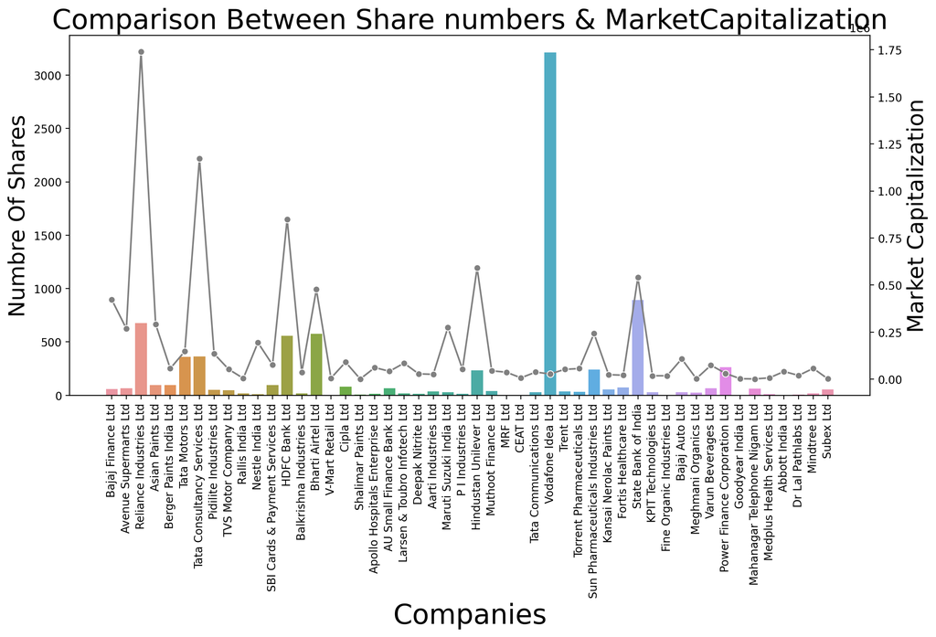

```python
plt.figure(figsize=(13,6), dpi=200)
plt.xticks(rotation=90)
plt.title('Comparison Between Share numbers & MarketCapitalization',size=25)
chart_1=sns.barplot(data=share_num, x='COMPANY', y='NUM_OF_SHARES(in Cr.)',)
plt.ylabel('Numbre Of Shares',size=20)
plt.xlabel('Companies',size=25)
chart_2=chart_1.twinx()
sns.lineplot(data=share_num, x='COMPANY', y='MARKET_CAP(in Cr.)', marker='o', color='grey')
plt.ylabel('Market Capitalization',size=20)
```

## 6.3 Number Of Companies On Each Sector

```python
df_sector=df[['SECTOR','COMPANY']].groupby('SECTOR').count().reset_index()
df_sector
```

|  | SECTOR | COMPANY |
| --- | --- | --- |
| 0 | Agro Chemicals | 3 |
| 1 | Automobile | 4 |
| 2 | Banks | 3 |
| 3 | Chemicals | 4 |
| 4 | FMCG | 3 |
| 5 | Finance | 4 |
| 6 | Healthcare | 3 |
| 7 | IT - Software | 5 |
| 8 | Paints/Varnish | 4 |
| 9 | Pharmaceuticals | 4 |
| 10 | Refineries | 1 |
| 11 | Retail | 4 |
| 12 | Telecomm-Service | 4 |
| 13 | Tyres | 4 |

### 6.3.1 Visualization

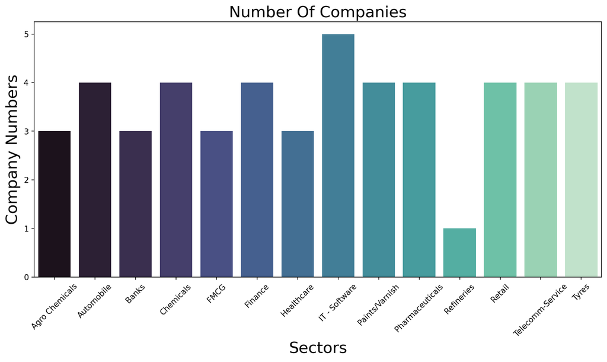

```python
plt.figure(figsize=(13,6), dpi=150)
plt.xticks(rotation=45)
plt.title('Number Of Companies',size=20)
sns.barplot(data=df_sector, x='SECTOR', y='COMPANY',palette='mako')
plt.xlabel('Sectors',size=20)
plt.ylabel('Company Numbers',size=20)
```

## 6.4 Number Of Companies According To Market Capitalization

- So, in stock market every one has different theory to keep the companies in different size capitalization. I am doing the differentiation on the basis of their Market capitalization

```python
SMALL_CAP_COUNT=0
MID_CAP_COUNT=0
LARGE_CAP_COUNT=0
BLUE_CHIP_COUNT=0

MARKET_CAP_DICT={}

MARKET_CAPITAL=list(df['MARKET_CAP(in Cr.)'])

for CAPITAL in MARKET_CAPITAL:
    if CAPITAL<50000:
        SMALL_CAP_COUNT+=1
        MARKET_CAP_DICT['SMALL_CAP']=SMALL_CAP_COUNT
    elif CAPITAL>50000 and CAPITAL<100000:
        MID_CAP_COUNT+=1
        MARKET_CAP_DICT['MID_CAP']=MID_CAP_COUNT
    elif CAPITAL>100000 and CAPITAL<1000000:
        LARGE_CAP_COUNT+=1
        MARKET_CAP_DICT['LARGE_CAP']=LARGE_CAP_COUNT
    elif CAPITAL>1000000:
        BLUE_CHIP_COUNT+=1
        MARKET_CAP_DICT['BLUE_CHIP']=BLUE_CHIP_COUNT

MARKET_CAP_DF=pd.DataFrame({'POSITION':MARKET_CAP_DICT.keys(),'NUMBER_OF_COMPANY':MARKET_CAP_DICT.values()})
MARKET_CAP_DF
```

|  | POSITION | NUMBER_OF_COMPANY |
| --- | --- | --- |
| 0 | LARGE_CAP | 13 |
| 1 | BLUE_CHIP | 2 |
| 2 | MID_CAP | 11 |
| 3 | SMALL_CAP | 24 |

### 6.4.1 Visualization

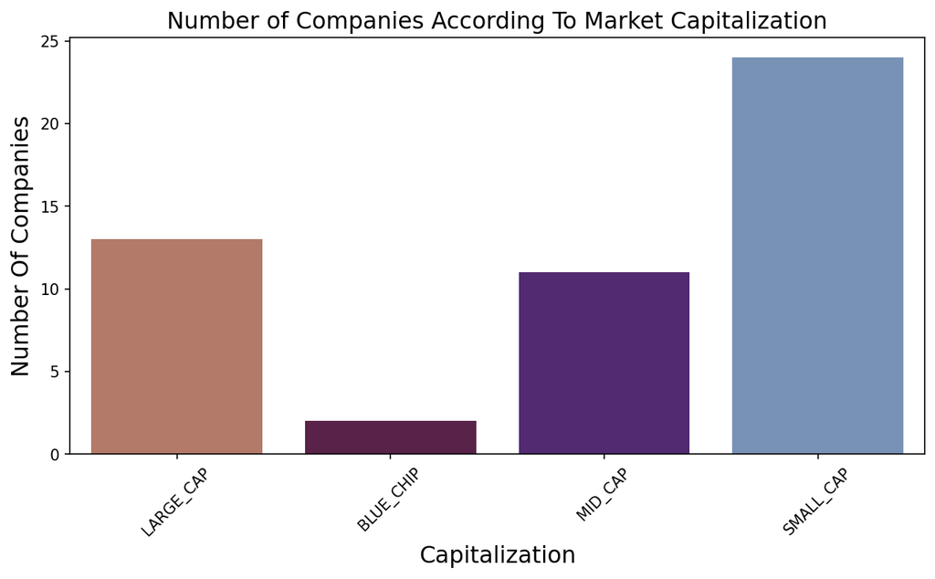

```python
plt.figure(figsize=(10,5),dpi=150)
plt.xticks(rotation=45)
plt.title('Number of Companies According To Market Capitalization',size=15)
sns.barplot(data=MARKET_CAP_DF, x='POSITION', y='NUMBER_OF_COMPANY', palette='twilight_r')
plt.xlabel('Capitalization',size=15)
plt.ylabel('Number Of Companies',size=15)
```

- So, as in above method use proper coding to get which company belongs to which Cap but we also have Masking method to do the same task

```python
MARKET_CAP_DICT={'SMALL_CAP':len(df[(df['MARKET_CAP(in Cr.)']<50000)]),\
                 'MID_CAP':len(df[(df['MARKET_CAP(in Cr.)']>50000)&(df['MARKET_CAP(in Cr.)']<100000)]),\
                'LARGE_CAP':len(df[(df['MARKET_CAP(in Cr.)']>100000) & (df['MARKET_CAP(in Cr.)']<1000000)]),\
                "BLUE_CHIP":len(df[(df['MARKET_CAP(in Cr.)']>1000000)])}
MARKET_CAP_DF=pd.DataFrame({'POSITION':MARKET_CAP_DICT.keys(),'NUMBER_OF_COMPANY':MARKET_CAP_DICT.values()})
MARKET_CAP_DF
```

|  | POSITION | NUMBER_OF_COMPANY |
| --- | --- | --- |
| 0 | SMALL_CAP | 24 |
| 1 | MID_CAP | 11 |
| 2 | LARGE_CAP | 13 |
| 3 | BLUE_CHIP | 2 |

## 6.5 Company according to their sectors

```python
df_sectors=df[['COMPANY','SECTOR','MARKET_CAP(in Cr.)']].copy()
```

```python
market_cap=df['MARKET_CAP(in Cr.)']

names=[]
for i in market_cap:
    if i<50000:
        a='SMALL_CAP'
        names.append(a)
    elif i>50000 and i<100000:
        b='MID_CAP'
        names.append(b)
    elif i>100000 and i<1000000:
        c='LARGE_CAP'
        names.append(c)
    elif i>1000000:
        d='BLUE_CHIP'
        names.append(d)
df_sectors["POSITION_"]=names
```

```python
df_sectors
```

|  | COMPANY | SECTOR | MARKET_CAP(in Cr.) | POSITION_ |
| --- | --- | --- | --- | --- |
| 0 | Bajaj Finance Ltd | Finance | 422293 | LARGE_CAP |
| 1 | Avenue Supermarts Ltd | Retail | 268104 | LARGE_CAP |
| 2 | Reliance Industries Ltd | Refineries | 1740392 | BLUE_CHIP |
| 3 | Asian Paints Ltd | Paints/Varnish | 292090 | LARGE_CAP |
| 4 | Berger Paints India Ltd | Paints/Varnish | 56644 | MID_CAP |
| 5 | Tata Motors Ltd | Automobile | 148207 | LARGE_CAP |
| 6 | Tata Consultancy Services Ltd | IT - Software | 1172964 | BLUE_CHIP |
| 7 | Pidilite Industries Ltd | Chemicals | 135022 | LARGE_CAP |
| 8 | TVS Motor Company Ltd | Automobile | 52544 | MID_CAP |
| 9 | Rallis India Ltd | Agro Chemicals | 4385 | SMALL_CAP |
| 10 | Nestle India Ltd | FMCG | 194522 | LARGE_CAP |
| 11 | SBI Cards & Payment Services Ltd | Finance | 76228 | MID_CAP |
| 12 | HDFC Bank Ltd | Banks | 849930 | LARGE_CAP |
| 13 | Balkrishna Industries Ltd | Tyres | 36364 | SMALL_CAP |
| 14 | Bharti Airtel Ltd | Telecomm-Service | 476676 | LARGE_CAP |
| 15 | V-Mart Retail Ltd | Retail | 5594 | SMALL_CAP |
| 16 | Cipla Ltd | Pharmaceuticals | 90575 | MID_CAP |
| 17 | Shalimar Paints Ltd | Paints/Varnish | 1121 | SMALL_CAP |
| 18 | Apollo Hospitals Enterprise Ltd | Healthcare | 61618 | MID_CAP |
| 19 | AU Small Finance Bank Ltd | Banks | 41871 | SMALL_CAP |
| 20 | Larsen & Toubro Infotech Ltd | IT - Software | 85278 | MID_CAP |
| 21 | Deepak Nitrite Ltd | Chemicals | 28361 | SMALL_CAP |
| 22 | Aarti Industries Ltd | Chemicals | 25673 | SMALL_CAP |
| 23 | Maruti Suzuki India Ltd | Automobile | 274810 | LARGE_CAP |
| 24 | P I Industries Ltd | Agro Chemicals | 53018 | MID_CAP |
| 25 | Hindustan Unilever Ltd | FMCG | 590593 | LARGE_CAP |
| 26 | Muthoot Finance Ltd | Finance | 44377 | SMALL_CAP |
| 27 | MRF Ltd | Tyres | 37087 | SMALL_CAP |
| 28 | CEAT Ltd | Tyres | 6966 | SMALL_CAP |
| 29 | Tata Communications Ltd | Telecomm-Service | 37453 | SMALL_CAP |
| 30 | Vodafone Idea Ltd | Telecomm-Service | 27783 | SMALL_CAP |
| 31 | Trent Ltd | Retail | 52289 | MID_CAP |
| 32 | Torrent Pharmaceuticals Ltd | Pharmaceuticals | 56339 | MID_CAP |
| 33 | Sun Pharmaceuticals Industries Ltd | Pharmaceuticals | 242489 | LARGE_CAP |
| 34 | Kansai Nerolac Paints Ltd | Paints/Varnish | 23896 | SMALL_CAP |
| 35 | Fortis Healthcare Ltd | Healthcare | 21094 | SMALL_CAP |
| 36 | State Bank of India | Banks | 540608 | LARGE_CAP |
| 37 | KPIT Technologies Ltd | IT - Software | 18200 | SMALL_CAP |
| 38 | Fine Organic Industries Ltd | Chemicals | 18207 | SMALL_CAP |
| 39 | Bajaj Auto Ltd | Automobile | 107778 | LARGE_CAP |
| 40 | Meghmani Organics Ltd | Agro Chemicals | 2941 | SMALL_CAP |
| 41 | Varun Beverages Ltd | FMCG | 73987 | MID_CAP |
| 42 | Power Finance Corporation Ltd | Finance | 30836 | SMALL_CAP |
| 43 | Goodyear India Ltd | Tyres | 2481 | SMALL_CAP |
| 44 | Mahanagar Telephone Nigam Ltd | Telecomm-Service | 1373 | SMALL_CAP |
| 45 | Medplus Health Services Ltd | Retail | 6904 | SMALL_CAP |
| 46 | Abbott India Ltd | Pharmaceuticals | 40883 | SMALL_CAP |
| 47 | Dr Lal Pathlabs Ltd | Healthcare | 19670 | SMALL_CAP |
| 48 | Mindtree Ltd | IT - Software | 57401 | MID_CAP |
| 49 | Subex Ltd | IT - Software | 1725 | SMALL_CAP |

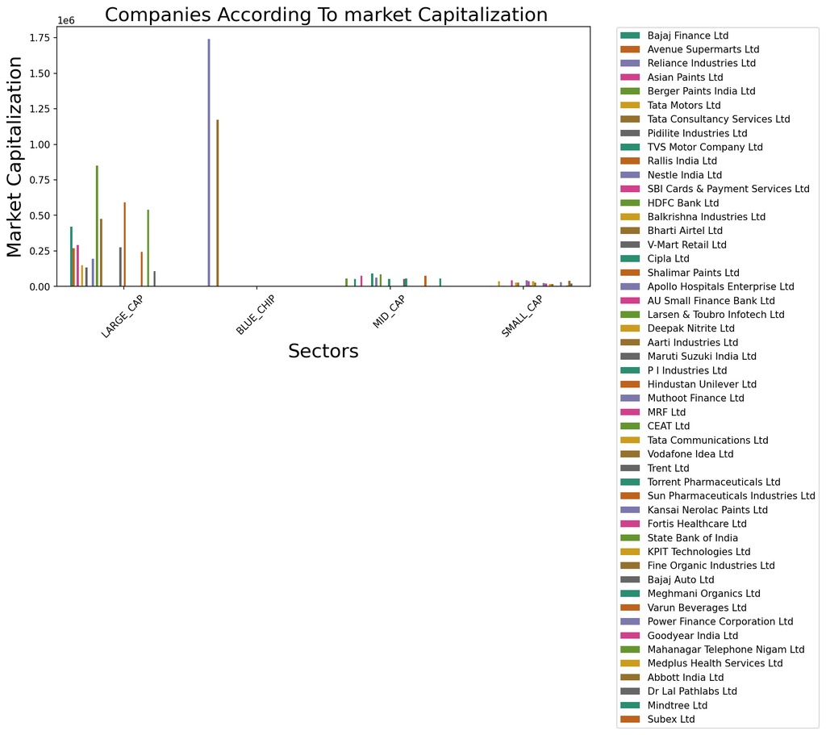

```python
plt.figure(figsize=(10,5),dpi=150)
plt.xticks(rotation=45)
plt.title(' Companies According To market Capitalization',size=20)
sns.barplot(data=df_sectors, x='POSITION_', y='MARKET_CAP(in Cr.)',hue='COMPANY', palette='Dark2' )
plt.xlabel('Sectors',size=20)
plt.ylabel('Market Capitalization',size=20)
plt.legend(loc=(1.05,-1.7))
```

## 6.6 Loss making Sector & Companies Detail

Details of those companies which have negative earnings which show that the companies are in loss

```python
loss_companies=df[df['EPS']<0]
loss_companies
```

|  | COMPANY | NSE_CODE | BSE_CODE | SECTOR | MARKET_CAP(in Cr.) | CURRENT_PRICE | DOWN_FROM_52w_HIGH(in %) | UP_FROM_52w_LOW(in %) | DEBT(in Cr.) | DIV_YIELD(in %) | BOOK_VALUE | PROMOTER_HOLDING(in %) | HOLDING_PLEDGED(in %) | SALES(in %) | SALES_GROWTH_5yrs(in %) | PROFIT(in %) | PROFIT_GROWTH_5yrs(in %) | ROCE(in %) | ROCE_5yr_AVG(in %) | ROE(in %) | ROE_5yr_AVG(in %) | PE_RATIO | PE_RATIO_5yr_AVG | CAGR_5yr(in %) | CAGR_10yr(in %) | EPS | ASSET_TURNOVER | QUICK_RATIO | DEBT_EQUITY_RATIO |
| --- | --- | --- | --- | --- | --- | --- | --- | --- | --- | --- | --- | --- | --- | --- | --- | --- | --- | --- | --- | --- | --- | --- | --- | --- | --- | --- | --- | --- | --- |
| 5 | Tata Motors Ltd | TATAMOTORS | 500570 | Automobile | 148207 | 412.00 | 23.2 | 12.6 | 144354.0 | 0.0 | 78.8 | 46.4 | 1.82 | 3.47 | 0.64 | -30209.00 | 0.00 | 1.40 | 3.44 | -22.3 | -5.2 | 0.0 | -2.12 | -0.49 | 4.15 | -25.6 | 0.83 | 0.68 | 5.52 |
| 17 | Shalimar Paints Ltd | SHALPAINTS | 509874 | Paints/Varnish | 1121 | 155.00 | 15.8 | 64.0 | 145.0 | 0.0 | 51.5 | 39.9 | 0.00 | 16.30 | 0.47 | 17.90 | 0.00 | -7.19 | -9.53 | -18.0 | -21.4 | 0.0 | -10.70 | 0.54 | 5.17 | -9.0 | 0.61 | 1.36 | 0.39 |
| 30 | Vodafone Idea Ltd | IDEA | 532822 | Telecomm-Service | 27783 | 8.65 | 48.5 | 11.6 | 248176.0 | 0.0 | -23.8 | 75.0 | 0.00 | 4.92 | 1.60 | -6.46 | 0.00 | 0.00 | 0.00 | 0.0 | 0.0 | 0.0 | -0.60 | -31.80 | -17.00 | -9.2 | 0.19 | 0.24 | 0.00 |
| 44 | Mahanagar Telephone Nigam Ltd | MTNL | 500108 | Telecomm-Service | 1373 | 21.80 | 46.6 | 30.9 | 26820.0 | 0.0 | -296.0 | 56.9 | 0.00 | -16.80 | -17.30 | -2.26 | 2.17 | -5.08 | -11.30 | 0.0 | 0.0 | 0.0 | -0.48 | -0.89 | -2.19 | -40.8 | 0.09 | 0.43 | 0.00 |

Getting the number of loss making companies according to sector.

```python
high_loss_sector=loss_companies[['SECTOR','COMPANY']].groupby('SECTOR').count().reset_index()
high_loss_sector
```

|  | SECTOR | COMPANY |
| --- | --- | --- |
| 0 | Automobile | 1 |
| 1 | Paints/Varnish | 1 |
| 2 | Telecomm-Service | 2 |

### 6.6.1 Visualization of loss making Sector according to their companies

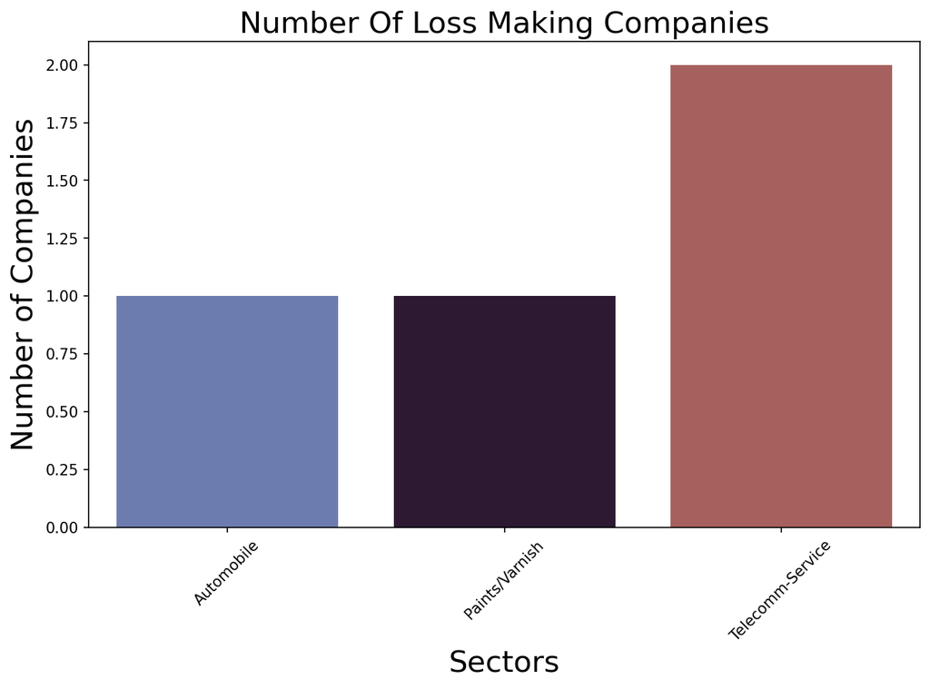

```python
plt.figure(figsize=(10,6), dpi=150)
plt.xticks(rotation=45)
plt.title('Number Of Loss Making Companies',size=20)
sns.barplot(data=high_loss_sector, x='SECTOR', y='COMPANY',palette='twilight')
plt.xlabel('Sectors',size=20)
plt.ylabel('Number of Companies',size=20)
```

- According to Data Set "Telecomm-Service" based Sector has high number of loss making companies

## 6.7 Profit making Sector & Companies Detail

```python
profit_companies=df[df['EPS']>0]
profit_companies
```

|  | COMPANY | NSE_CODE | BSE_CODE | SECTOR | MARKET_CAP(in Cr.) | CURRENT_PRICE | DOWN_FROM_52w_HIGH(in %) | UP_FROM_52w_LOW(in %) | DEBT(in Cr.) | DIV_YIELD(in %) | BOOK_VALUE | PROMOTER_HOLDING(in %) | HOLDING_PLEDGED(in %) | SALES(in %) | SALES_GROWTH_5yrs(in %) | PROFIT(in %) | PROFIT_GROWTH_5yrs(in %) | ROCE(in %) | ROCE_5yr_AVG(in %) | ROE(in %) | ROE_5yr_AVG(in %) | PE_RATIO | PE_RATIO_5yr_AVG | CAGR_5yr(in %) | CAGR_10yr(in %) | EPS | ASSET_TURNOVER | QUICK_RATIO | DEBT_EQUITY_RATIO |
| --- | --- | --- | --- | --- | --- | --- | --- | --- | --- | --- | --- | --- | --- | --- | --- | --- | --- | --- | --- | --- | --- | --- | --- | --- | --- | --- | --- | --- | --- |
| 0 | Bajaj Finance Ltd | BAJFINANCE | 500034 | Finance | 422293 | 6975.0 | 13.30 | 33.60 | 183273.0 | 0.29 | 794.0 | 55.9 | 0.00 | 30.10 | 26.00 | 99.40 | 30.90 | 10.30 | 11.00 | 17.50 | 17.70 | 42.60 | 40.70 | 31.90 | 48.50 | 164.00 | 0.16 | 1.26 | 3.81 |
| 1 | Avenue Supermarts Ltd | DMART | 540376 | Retail | 268104 | 4139.0 | 20.10 | 29.90 | 711.0 | 0.00 | 232.0 | 75.0 | 0.00 | 38.50 | 21.10 | 68.00 | 25.80 | 15.80 | 18.00 | 11.50 | 13.20 | 116.00 | 103.00 | 29.00 | 0.00 | 35.60 | 2.13 | 1.19 | 0.05 |
| 2 | Reliance Industries Ltd | RELIANCE | 500325 | Refineries | 1740392 | 2572.0 | 9.93 | 18.00 | 316030.0 | 0.31 | 1168.0 | 50.6 | 0.00 | 46.40 | 18.10 | 24.20 | 14.40 | 9.42 | 10.00 | 8.16 | 9.59 | 27.10 | 17.90 | 24.10 | 20.70 | 98.10 | 0.50 | 0.63 | 0.40 |
| 3 | Asian Paints Ltd | ASIANPAINT | 500820 | Paints/Varnish | 292090 | 3045.0 | 15.20 | 19.00 | 1866.0 | 0.63 | 147.0 | 52.6 | 10.60 | 28.20 | 14.10 | 15.60 | 9.71 | 29.70 | 33.60 | 23.20 | 25.40 | 77.60 | 59.10 | 20.90 | 22.20 | 38.20 | 1.34 | 1.04 | 0.13 |
| 4 | Berger Paints India Ltd | BERGEPAINT | 509480 | Paints/Varnish | 56644 | 583.0 | 28.30 | 7.28 | 1634.0 | 0.53 | 42.2 | 75.0 | 0.00 | 24.50 | 14.00 | 12.20 | 14.10 | 25.90 | 27.20 | 22.50 | 22.90 | 59.90 | 63.60 | 18.30 | 27.70 | 9.74 | 1.33 | 0.58 | 0.40 |
| 6 | Tata Consultancy Services Ltd | TCS | 532540 | IT - Software | 1172964 | 3206.0 | 20.80 | 9.56 | 7460.0 | 1.34 | 266.0 | 72.3 | 0.48 | 16.60 | 10.20 | 8.27 | 7.83 | 54.90 | 47.80 | 43.60 | 37.20 | 29.60 | 21.20 | 18.80 | 17.10 | 108.00 | 1.42 | 2.84 | 0.08 |
| 7 | Pidilite Industries Ltd | PIDILITIND | 500331 | Chemicals | 135022 | 2656.0 | 9.00 | 33.60 | 680.0 | 0.38 | 130.0 | 69.9 | 0.00 | 26.10 | 12.00 | -3.28 | 7.10 | 26.10 | 31.70 | 20.20 | 23.80 | 104.00 | 61.70 | 26.50 | 29.00 | 25.60 | 1.08 | 0.92 | 0.10 |
| 8 | TVS Motor Company Ltd | TVSMOTOR | 532343 | Automobile | 52544 | 1106.0 | 6.04 | 116.00 | 18675.0 | 0.34 | 107.0 | 50.8 | 0.00 | 24.20 | 14.30 | 41.50 | 8.13 | 11.30 | 13.20 | 18.40 | 20.80 | 44.40 | 39.30 | 9.31 | 39.50 | 25.60 | 1.00 | 0.89 | 3.68 |
| 9 | Rallis India Ltd | RALLIS | 500355 | Agro Chemicals | 4385 | 226.0 | 24.60 | 23.60 | 175.0 | 1.33 | 91.2 | 50.1 | 0.00 | 17.50 | 13.40 | -12.60 | 2.40 | 13.60 | 16.60 | 10.20 | 12.60 | 26.80 | 20.70 | 0.03 | 3.58 | 8.43 | 0.96 | 0.86 | 0.10 |
| 10 | Nestle India Ltd | NESTLEIND | 500790 | FMCG | 194522 | 20175.0 | 4.17 | 26.10 | 280.0 | 0.99 | 241.0 | 62.8 | 0.00 | 13.50 | 9.98 | 4.63 | 18.10 | 147.00 | 95.10 | 113.00 | 67.10 | 82.90 | 66.50 | 21.00 | 15.50 | 225.00 | 1.83 | 0.51 | 0.12 |
| 11 | SBI Cards & Payment Services Ltd | SBICARD | 543066 | Finance | 76228 | 807.0 | 26.30 | 23.00 | 28186.0 | 0.31 | 94.6 | 69.4 | 0.00 | 25.60 | 26.10 | 105.00 | 34.10 | 11.60 | 12.80 | 23.00 | 24.00 | 36.00 | 49.70 | 0.00 | 0.00 | 22.50 | 0.35 | 0.41 | 3.16 |
| 12 | HDFC Bank Ltd | HDFCBANK | 500180 | Banks | 849930 | 1525.0 | 11.50 | 19.90 | 1784970.0 | 1.02 | 446.0 | 25.6 | 0.00 | 13.90 | 13.20 | 22.00 | 20.00 | 5.83 | 6.77 | 16.60 | 16.80 | 20.40 | 24.20 | 10.80 | 16.80 | 75.20 | 0.07 | 2.66 | 7.22 |
| 13 | Balkrishna Industries Ltd | BALKRISIND | 502355 | Tyres | 36364 | 1881.0 | 25.90 | 11.80 | 2529.0 | 0.85 | 359.0 | 58.3 | 0.00 | 37.20 | 17.40 | 2.56 | 17.00 | 23.80 | 22.00 | 21.90 | 19.50 | 25.80 | 24.90 | 14.30 | 29.90 | 73.00 | 0.87 | 0.48 | 0.36 |
| 14 | Bharti Airtel Ltd | BHARTIARTL | 532454 | Telecomm-Service | 476676 | 826.0 | 1.87 | 31.30 | 217989.0 | 0.36 | 131.0 | 55.1 | 0.00 | 19.80 | 4.07 | 125.00 | -3.36 | 12.00 | 8.30 | 5.86 | 2.13 | 76.70 | 36.80 | 12.70 | 12.50 | 11.40 | 0.33 | 0.45 | 2.99 |
| 15 | V-Mart Retail Ltd | VMART | 534976 | Retail | 5594 | 2830.0 | 41.60 | 17.60 | 902.0 | 0.03 | 430.0 | 46.1 | 0.00 | 76.80 | 10.70 | 4888.00 | -22.40 | 5.21 | 11.40 | 1.46 | 7.58 | 92.00 | 44.20 | 15.00 | 0.00 | 30.80 | 0.89 | 0.28 | 1.06 |
| 16 | Cipla Ltd | CIPLA | 500087 | Pharmaceuticals | 90575 | 1122.0 | 5.31 | 32.00 | 1068.0 | 0.45 | 271.0 | 33.6 | 0.00 | 5.50 | 8.62 | -2.62 | 23.10 | 17.50 | 13.60 | 13.20 | 11.30 | 34.90 | 27.90 | 13.00 | 11.00 | 31.80 | 0.84 | 1.97 | 0.05 |
| 18 | Apollo Hospitals Enterprise Ltd | APOLLOHOSP | 508869 | Healthcare | 61618 | 4285.0 | 27.80 | 27.50 | 3998.0 | 0.27 | 417.0 | 29.3 | 16.40 | 16.20 | 15.10 | 7.82 | 44.80 | 17.80 | 11.80 | 16.60 | 7.94 | 73.40 | 72.40 | 33.80 | 18.00 | 58.40 | 1.19 | 1.32 | 0.67 |
| 19 | AU Small Finance Bank Ltd | AUBANK | 540611 | Banks | 41871 | 628.0 | 14.30 | 35.90 | 58575.0 | 0.08 | 119.0 | 25.6 | 0.00 | 31.30 | 35.80 | 11.40 | 6.58 | 7.19 | 8.47 | 16.60 | 17.90 | 33.30 | 34.70 | 15.80 | 0.00 | 19.70 | 0.10 | 2.31 | 7.84 |
| 20 | Larsen & Toubro Infotech Ltd | LTI | 540005 | IT - Software | 85278 | 4862.0 | 36.00 | 30.20 | 824.0 | 0.93 | 524.0 | 74.0 | 0.00 | 30.40 | 19.20 | 21.30 | 19.20 | 35.70 | 38.60 | 28.50 | 30.50 | 33.30 | 19.50 | 38.80 | 0.00 | 146.00 | 1.35 | 3.09 | 0.09 |
| 21 | Deepak Nitrite Ltd | DEEPAKNTR | 506401 | Chemicals | 28361 | 2079.0 | 22.70 | 23.70 | 270.0 | 0.34 | 268.0 | 45.7 | 0.00 | 28.90 | 37.80 | -13.60 | 87.00 | 44.50 | 32.80 | 37.40 | 34.20 | 30.90 | 21.50 | 57.00 | 57.00 | 67.40 | 1.70 | 2.26 | 0.07 |
| 22 | Aarti Industries Ltd | AARTIIND | 524208 | Chemicals | 25673 | 708.0 | 30.30 | 16.60 | 2594.0 | 0.49 | 163.0 | 44.2 | 0.00 | 56.70 | 17.20 | 120.00 | 32.90 | 22.10 | 17.60 | 27.80 | 22.20 | 19.30 | 26.50 | 29.10 | 42.40 | 36.70 | 0.81 | 0.80 | 0.44 |
| 23 | Maruti Suzuki India Ltd | MARUTI | 532500 | Automobile | 274810 | 9097.0 | 6.88 | 39.20 | 625.0 | 0.66 | 1893.0 | 56.4 | 0.00 | 24.00 | 5.34 | 44.40 | -7.94 | 8.95 | 13.60 | 7.25 | 10.20 | 45.30 | 26.30 | 2.14 | 20.10 | 201.00 | 1.21 | 0.80 | 0.01 |
| 24 | P I Industries Ltd | PIIND | 523642 | Agro Chemicals | 53018 | 3494.0 | 5.52 | 49.80 | 280.0 | 0.17 | 436.0 | 46.1 | 0.00 | 23.60 | 18.40 | 29.30 | 12.90 | 17.30 | 21.20 | 14.70 | 17.50 | 51.80 | 34.70 | 33.20 | 41.90 | 67.50 | 0.72 | 2.53 | 0.04 |
| 25 | Hindustan Unilever Ltd | HINDUNILVR | 500696 | FMCG | 590593 | 2514.0 | 8.06 | 32.20 | 1139.0 | 1.35 | 211.0 | 61.9 | 0.00 | 14.30 | 9.60 | 14.70 | 15.60 | 24.30 | 48.30 | 18.40 | 35.80 | 61.00 | 55.20 | 14.30 | 16.90 | 41.10 | 0.75 | 0.99 | 0.02 |
| 26 | Muthoot Finance Ltd | MUTHOOTFIN | 533398 | Finance | 44377 | 1105.0 | 35.80 | 16.40 | 46770.0 | 1.81 | 479.0 | 73.4 | 0.00 | -5.33 | 14.00 | -7.43 | 27.40 | 14.20 | 15.60 | 23.60 | 25.40 | 12.10 | 12.50 | 18.00 | 17.20 | 91.20 | 0.17 | 3.29 | 2.43 |
| 27 | MRF Ltd | MRF | 500290 | Tyres | 37087 | 87469.0 | 8.89 | 39.00 | 3118.0 | 0.17 | 33566.0 | 27.9 | 0.00 | 17.20 | 7.57 | -53.00 | -14.90 | 7.05 | 12.60 | 4.85 | 9.76 | 65.30 | 21.80 | 5.36 | 24.00 | 1339.00 | 0.85 | 0.78 | 0.22 |
| 28 | CEAT Ltd | CEATLTD | 500878 | Tyres | 6966 | 1722.0 | 3.68 | 93.50 | 2393.0 | 0.17 | 809.0 | 47.2 | 0.00 | 20.80 | 10.20 | -89.30 | -25.50 | 6.35 | 11.60 | 2.59 | 9.28 | 182.00 | 14.80 | -0.14 | 32.10 | 5.52 | 1.08 | 0.36 | 0.73 |
| 29 | Tata Communications Ltd | TATACOMM | 500483 | Telecomm-Service | 37453 | 1314.0 | 17.40 | 53.50 | 8840.0 | 1.58 | 31.8 | 58.9 | 4.96 | 3.72 | -1.04 | 34.20 | -6.74 | 21.80 | 13.20 | 282.00 | 0.00 | 21.10 | 16.70 | 24.60 | 24.40 | 64.40 | 0.82 | 0.61 | 9.74 |
| 31 | Trent Ltd | TRENT | 500251 | Retail | 52289 | 1471.0 | 6.37 | 51.60 | 4526.0 | 0.12 | 67.0 | 37.0 | 0.00 | 92.00 | 19.90 | 550.00 | -14.40 | 9.29 | 9.60 | 1.60 | 1.76 | 176.00 | 124.00 | 36.40 | 29.00 | 10.20 | 0.67 | 0.79 | 1.90 |
| 32 | Torrent Pharmaceuticals Ltd | TORNTPHARM | 500420 | Pharmaceuticals | 56339 | 1665.0 | 4.88 | 34.00 | 4083.0 | 0.24 | 180.0 | 71.2 | 0.00 | 8.19 | 7.91 | -5.29 | 4.12 | 18.90 | 15.50 | 18.30 | 18.10 | 47.00 | 32.60 | 22.10 | 25.80 | 23.60 | 0.63 | 0.73 | 0.67 |
| 33 | Sun Pharmaceuticals Industries Ltd | SUNPHARMA | 524715 | Pharmaceuticals | 242489 | 1011.0 | 5.63 | 37.80 | 4366.0 | 0.99 | 221.0 | 54.5 | 4.04 | 11.80 | 4.13 | 9.17 | -0.99 | 18.40 | 12.90 | 14.00 | 10.20 | 30.60 | 43.10 | 13.90 | 11.40 | 17.10 | 0.56 | 1.74 | 0.08 |
| 34 | Kansai Nerolac Paints Ltd | KANSAINER | 500165 | Paints/Varnish | 23896 | 443.0 | 29.60 | 23.80 | 314.0 | 0.51 | 80.9 | 75.0 | 0.00 | 20.70 | 9.46 | -22.50 | -6.75 | 11.40 | 18.10 | 8.12 | 12.80 | 58.60 | 53.00 | -2.48 | 15.70 | 7.84 | 1.13 | 1.24 | 0.07 |
| 35 | Fortis Healthcare Ltd | FORTIS | 532843 | Healthcare | 21094 | 279.0 | 14.00 | 27.10 | 1255.0 | 0.00 | 81.8 | 31.2 | 0.00 | 19.90 | 4.57 | 120.00 | -2.33 | 10.80 | 5.50 | 6.12 | 0.31 | 51.60 | 22.20 | 15.80 | 10.50 | 5.48 | 0.51 | 0.80 | 0.20 |
| 36 | State Bank of India | SBIN | 500112 | Banks | 540608 | 606.0 | 2.75 | 42.50 | 4536570.0 | 1.17 | 342.0 | 57.5 | 0.00 | 10.40 | 4.70 | 21.70 | 160.00 | 4.44 | 4.56 | 12.20 | 5.81 | 13.10 | 12.40 | 12.70 | 10.80 | 46.10 | 0.06 | 3.06 | 14.80 |
| 37 | KPIT Technologies Ltd | KPITTECH | 542651 | IT - Software | 18200 | 664.0 | 17.10 | 69.70 | 186.0 | 0.47 | 50.8 | 40.1 | 0.82 | 22.10 | 0.00 | 46.60 | 0.00 | 24.10 | 0.00 | 21.50 | 0.00 | 57.30 | 32.70 | 0.00 | 0.00 | 11.60 | 1.13 | 2.02 | 0.13 |
| 38 | Fine Organic Industries Ltd | FINEORG | 541557 | Chemicals | 18207 | 5938.0 | 19.00 | 81.60 | 45.0 | 0.15 | 420.0 | 75.0 | 0.00 | 93.70 | 19.20 | 267.00 | 27.20 | 38.80 | 34.10 | 30.70 | 26.80 | 34.00 | 35.50 | 0.00 | 0.00 | 175.00 | 1.72 | 2.61 | 0.03 |
| 39 | Bajaj Auto Ltd | BAJAJ-AUTO | 532977 | Automobile | 107778 | 3725.0 | 9.85 | 23.00 | 124.0 | 3.76 | 900.0 | 54.8 | 0.01 | 4.61 | 8.79 | -7.75 | 5.87 | 23.40 | 27.50 | 19.00 | 20.90 | 19.30 | 17.10 | 2.74 | 7.29 | 202.00 | 0.96 | 1.58 | 0.00 |
| 40 | Meghmani Organics Ltd | MOL | 543331 | Agro Chemicals | 2941 | 116.0 | 24.20 | 43.20 | 665.0 | 1.21 | 63.1 | 49.4 | 0.00 | 47.20 | 0.00 | 59.70 | 0.00 | 24.10 | 0.00 | 22.60 | 0.00 | 8.51 | 8.71 | 0.00 | 0.00 | 13.60 | 1.05 | 0.71 | 0.41 |
| 41 | Varun Beverages Ltd | VBL | 540180 | FMCG | 73987 | 1139.0 | 7.62 | 109.00 | 2371.0 | 0.22 | 74.1 | 63.9 | 0.04 | 50.80 | 18.00 | 115.00 | 72.10 | 17.40 | 14.60 | 18.60 | 15.30 | 51.40 | 55.40 | 50.30 | 0.00 | 22.20 | 0.98 | 0.34 | 0.49 |
| 42 | Power Finance Corporation Ltd | PFC | 532810 | Finance | 30836 | 117.0 | 17.90 | 20.30 | 674847.0 | 10.30 | 290.0 | 56.0 | 0.00 | 1.44 | 22.60 | 8.39 | 44.40 | 9.38 | 9.66 | 21.20 | 19.70 | 2.18 | 3.28 | -1.61 | 2.15 | 53.60 | 0.10 | 1.51 | 8.82 |
| 43 | Goodyear India Ltd | GOODYEAR | 500168 | Tyres | 2481 | 1075.0 | 10.80 | 37.30 | 16.7 | 1.86 | 310.0 | 74.0 | 0.00 | 29.60 | 10.00 | -32.20 | -4.15 | 18.00 | 19.50 | 13.20 | 13.50 | 21.80 | 15.70 | 6.03 | 12.90 | 49.30 | 1.77 | 1.08 | 0.02 |
| 45 | Medplus Health Services Ltd | MEDPLUS | 543427 | Retail | 6904 | 579.0 | 56.90 | 1.52 | 815.0 | 0.00 | 119.0 | 40.4 | 50.50 | 23.10 | 13.40 | 49.40 | 25.70 | 11.40 | 12.00 | 10.40 | 9.25 | 134.00 | 126.00 | 0.00 | 0.00 | 9.00 | 1.82 | 1.28 | 0.57 |
| 46 | Abbott India Ltd | ABBOTINDIA | 500488 | Pharmaceuticals | 40883 | 19239.0 | 7.95 | 24.00 | 152.0 | 0.75 | 1327.0 | 75.0 | 0.00 | 12.20 | 11.10 | 14.50 | 23.60 | 38.40 | 37.10 | 29.50 | 27.00 | 50.60 | 35.70 | 33.60 | 29.40 | 381.00 | 1.22 | 2.63 | 0.05 |
| 47 | Dr Lal Pathlabs Ltd | LALPATHLAB | 539524 | Healthcare | 19670 | 2360.0 | 40.20 | 30.70 | 285.0 | 0.51 | 186.0 | 55.0 | 0.00 | 1.53 | 18.00 | -38.60 | 17.40 | 29.40 | 32.40 | 25.10 | 24.00 | 79.30 | 51.70 | 22.60 | 0.00 | 29.80 | 1.04 | 1.73 | 0.18 |
| 48 | Mindtree Ltd | MINDTREE | 532819 | IT - Software | 57401 | 3480.0 | 31.20 | 31.40 | 613.0 | 1.06 | 344.0 | 61.0 | 0.00 | 35.00 | 15.00 | 36.40 | 31.60 | 41.50 | 33.40 | 33.80 | 26.90 | 30.40 | 21.60 | 47.80 | 35.00 | 115.00 | 1.45 | 2.96 | 0.11 |
| 49 | Subex Ltd | SUBEXLTD | 532348 | IT - Software | 1725 | 30.6 | 50.10 | 64.50 | 14.7 | 0.00 | 10.1 | 0.0 | 0.00 | -7.65 | -1.37 | -73.20 | -19.90 | 6.18 | 8.34 | 3.68 | 5.34 | 132.00 | 20.80 | 28.30 | 7.80 | 0.23 | 0.46 | 3.75 | 0.03 |

```python
high_profit_sector=profit_companies[['SECTOR','COMPANY']].groupby('SECTOR').count().reset_index()
high_profit_sector
```

|  | SECTOR | COMPANY |
| --- | --- | --- |
| 0 | Agro Chemicals | 3 |
| 1 | Automobile | 3 |
| 2 | Banks | 3 |
| 3 | Chemicals | 4 |
| 4 | FMCG | 3 |
| 5 | Finance | 4 |
| 6 | Healthcare | 3 |
| 7 | IT - Software | 5 |
| 8 | Paints/Varnish | 3 |
| 9 | Pharmaceuticals | 4 |
| 10 | Refineries | 1 |
| 11 | Retail | 4 |
| 12 | Telecomm-Service | 2 |
| 13 | Tyres | 4 |

### Visualization of profit making Sector according to their companies

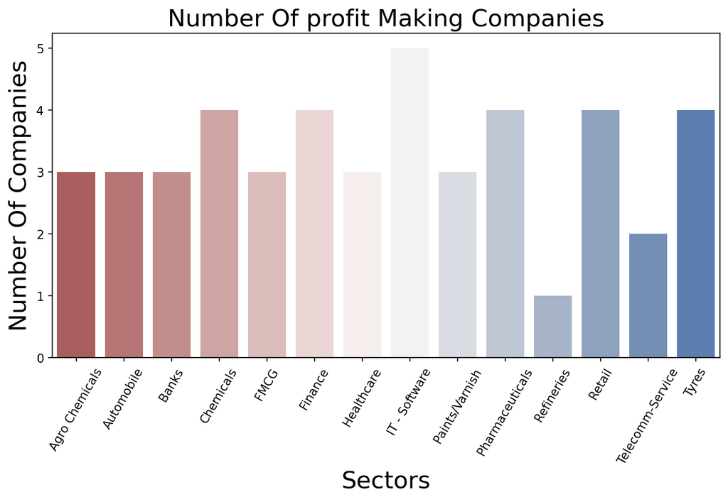

```python
plt.figure(figsize=(10,5), dpi=150)
plt.xticks(rotation=60)
plt.title('Number Of profit Making Companies',size=20)
sns.barplot(data=high_profit_sector, x='SECTOR', y='COMPANY',palette='vlag_r')
plt.xlabel('Sectors',size=20)
plt.ylabel('Number Of Companies',size=20)
```

- As per above analysis "Telecomm-Service" Sector has equal profit making and loss making companies so according to data set investing in this sector will not give handsome returns
- To make sure this thing we do more analysis on "Telecomm-Service" Sector

# 7 "Telecomm-Service" SECTOR ANALYSIS

```python
Tele_sector=df[df['SECTOR']=='Telecomm-Service']
Tele_sector
```

|  | COMPANY | NSE_CODE | BSE_CODE | SECTOR | MARKET_CAP(in Cr.) | CURRENT_PRICE | DOWN_FROM_52w_HIGH(in %) | UP_FROM_52w_LOW(in %) | DEBT(in Cr.) | DIV_YIELD(in %) | BOOK_VALUE | PROMOTER_HOLDING(in %) | HOLDING_PLEDGED(in %) | SALES(in %) | SALES_GROWTH_5yrs(in %) | PROFIT(in %) | PROFIT_GROWTH_5yrs(in %) | ROCE(in %) | ROCE_5yr_AVG(in %) | ROE(in %) | ROE_5yr_AVG(in %) | PE_RATIO | PE_RATIO_5yr_AVG | CAGR_5yr(in %) | CAGR_10yr(in %) | EPS | ASSET_TURNOVER | QUICK_RATIO | DEBT_EQUITY_RATIO |
| --- | --- | --- | --- | --- | --- | --- | --- | --- | --- | --- | --- | --- | --- | --- | --- | --- | --- | --- | --- | --- | --- | --- | --- | --- | --- | --- | --- | --- | --- |
| 14 | Bharti Airtel Ltd | BHARTIARTL | 532454 | Telecomm-Service | 476676 | 826.00 | 1.87 | 31.3 | 217989.0 | 0.36 | 131.0 | 55.1 | 0.00 | 19.80 | 4.07 | 125.00 | -3.36 | 12.00 | 8.3 | 5.86 | 2.13 | 76.7 | 36.80 | 12.70 | 12.50 | 11.4 | 0.33 | 0.45 | 2.99 |
| 29 | Tata Communications Ltd | TATACOMM | 500483 | Telecomm-Service | 37453 | 1314.00 | 17.40 | 53.5 | 8840.0 | 1.58 | 31.8 | 58.9 | 4.96 | 3.72 | -1.04 | 34.20 | -6.74 | 21.80 | 13.2 | 282.00 | 0.00 | 21.1 | 16.70 | 24.60 | 24.40 | 64.4 | 0.82 | 0.61 | 9.74 |
| 30 | Vodafone Idea Ltd | IDEA | 532822 | Telecomm-Service | 27783 | 8.65 | 48.50 | 11.6 | 248176.0 | 0.00 | -23.8 | 75.0 | 0.00 | 4.92 | 1.60 | -6.46 | 0.00 | 0.00 | 0.0 | 0.00 | 0.00 | 0.0 | -0.60 | -31.80 | -17.00 | -9.2 | 0.19 | 0.24 | 0.00 |
| 44 | Mahanagar Telephone Nigam Ltd | MTNL | 500108 | Telecomm-Service | 1373 | 21.80 | 46.60 | 30.9 | 26820.0 | 0.00 | -296.0 | 56.9 | 0.00 | -16.80 | -17.30 | -2.26 | 2.17 | -5.08 | -11.3 | 0.00 | 0.00 | 0.0 | -0.48 | -0.89 | -2.19 | -40.8 | 0.09 | 0.43 | 0.00 |

## 7.1 Analyzing Debt and Market_Cap of Companies

- So, as a investor we should make sure that the debt which a company owns can repay smoothly and also invest the profit for it's growth

```python
Tele_sector[Tele_sector["MARKET_CAP(in Cr.)"]>Tele_sector["DEBT(in Cr.)"]]
```

|  | COMPANY | NSE_CODE | BSE_CODE | SECTOR | MARKET_CAP(in Cr.) | CURRENT_PRICE | DOWN_FROM_52w_HIGH(in %) | UP_FROM_52w_LOW(in %) | DEBT(in Cr.) | DIV_YIELD(in %) | BOOK_VALUE | PROMOTER_HOLDING(in %) | HOLDING_PLEDGED(in %) | SALES(in %) | SALES_GROWTH_5yrs(in %) | PROFIT(in %) | PROFIT_GROWTH_5yrs(in %) | ROCE(in %) | ROCE_5yr_AVG(in %) | ROE(in %) | ROE_5yr_AVG(in %) | PE_RATIO | PE_RATIO_5yr_AVG | CAGR_5yr(in %) | CAGR_10yr(in %) | EPS | ASSET_TURNOVER | QUICK_RATIO | DEBT_EQUITY_RATIO |
| --- | --- | --- | --- | --- | --- | --- | --- | --- | --- | --- | --- | --- | --- | --- | --- | --- | --- | --- | --- | --- | --- | --- | --- | --- | --- | --- | --- | --- | --- |
| 14 | Bharti Airtel Ltd | BHARTIARTL | 532454 | Telecomm-Service | 476676 | 826.0 | 1.87 | 31.3 | 217989.0 | 0.36 | 131.0 | 55.1 | 0.00 | 19.80 | 4.07 | 125.0 | -3.36 | 12.0 | 8.3 | 5.86 | 2.13 | 76.7 | 36.8 | 12.7 | 12.5 | 11.4 | 0.33 | 0.45 | 2.99 |
| 29 | Tata Communications Ltd | TATACOMM | 500483 | Telecomm-Service | 37453 | 1314.0 | 17.40 | 53.5 | 8840.0 | 1.58 | 31.8 | 58.9 | 4.96 | 3.72 | -1.04 | 34.2 | -6.74 | 21.8 | 13.2 | 282.00 | 0.00 | 21.1 | 16.7 | 24.6 | 24.4 | 64.4 | 0.82 | 0.61 | 9.74 |

### 7.1.1 Visualization

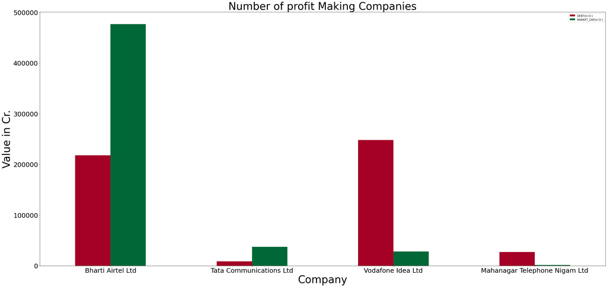

```python
Tele_sector.plot(x="COMPANY", y=["DEBT(in Cr.)","MARKET_CAP(in Cr.)"], kind="bar",figsize=(39,18),\
                 rot=0, title='Debt & Market_cap comparison',fontsize=25,colormap='RdYlGn' )
plt.xlabel('Company',size=40)
plt.ylabel('Value in Cr.',size=40)
plt.title('Number of profit Making Companies',size=40)
```

-So, in above analysis we can see 2 companies has debt more than there Market_Cap than we can avoid to invest in these companies

## 7.2 CAGR check

```python
Tele_sector[(Tele_sector['CAGR_5yr(in %)']>20)& (Tele_sector['CAGR_10yr(in %)']>20)]
```

|  | COMPANY | NSE_CODE | BSE_CODE | SECTOR | MARKET_CAP(in Cr.) | CURRENT_PRICE | DOWN_FROM_52w_HIGH(in %) | UP_FROM_52w_LOW(in %) | DEBT(in Cr.) | DIV_YIELD(in %) | BOOK_VALUE | PROMOTER_HOLDING(in %) | HOLDING_PLEDGED(in %) | SALES(in %) | SALES_GROWTH_5yrs(in %) | PROFIT(in %) | PROFIT_GROWTH_5yrs(in %) | ROCE(in %) | ROCE_5yr_AVG(in %) | ROE(in %) | ROE_5yr_AVG(in %) | PE_RATIO | PE_RATIO_5yr_AVG | CAGR_5yr(in %) | CAGR_10yr(in %) | EPS | ASSET_TURNOVER | QUICK_RATIO | DEBT_EQUITY_RATIO |
| --- | --- | --- | --- | --- | --- | --- | --- | --- | --- | --- | --- | --- | --- | --- | --- | --- | --- | --- | --- | --- | --- | --- | --- | --- | --- | --- | --- | --- | --- |
| 29 | Tata Communications Ltd | TATACOMM | 500483 | Telecomm-Service | 37453 | 1314.0 | 17.4 | 53.5 | 8840.0 | 1.58 | 31.8 | 58.9 | 4.96 | 3.72 | -1.04 | 34.2 | -6.74 | 21.8 | 13.2 | 282.0 | 0.0 | 21.1 | 16.7 | 24.6 | 24.4 | 64.4 | 0.82 | 0.61 | 9.74 |

The "IT-software" sector has highest profit making companies as per the Data set so will analyze this sector

# 8. "IT - Software" SECTOR ANALYSIS

```python
IT_sector=df[df['SECTOR']=='IT - Software']
IT_sector
```

|  | COMPANY | NSE_CODE | BSE_CODE | SECTOR | MARKET_CAP(in Cr.) | CURRENT_PRICE | DOWN_FROM_52w_HIGH(in %) | UP_FROM_52w_LOW(in %) | DEBT(in Cr.) | DIV_YIELD(in %) | BOOK_VALUE | PROMOTER_HOLDING(in %) | HOLDING_PLEDGED(in %) | SALES(in %) | SALES_GROWTH_5yrs(in %) | PROFIT(in %) | PROFIT_GROWTH_5yrs(in %) | ROCE(in %) | ROCE_5yr_AVG(in %) | ROE(in %) | ROE_5yr_AVG(in %) | PE_RATIO | PE_RATIO_5yr_AVG | CAGR_5yr(in %) | CAGR_10yr(in %) | EPS | ASSET_TURNOVER | QUICK_RATIO | DEBT_EQUITY_RATIO |
| --- | --- | --- | --- | --- | --- | --- | --- | --- | --- | --- | --- | --- | --- | --- | --- | --- | --- | --- | --- | --- | --- | --- | --- | --- | --- | --- | --- | --- | --- |
| 6 | Tata Consultancy Services Ltd | TCS | 532540 | IT - Software | 1172964 | 3206.0 | 20.8 | 9.56 | 7460.0 | 1.34 | 266.0 | 72.3 | 0.48 | 16.60 | 10.20 | 8.27 | 7.83 | 54.90 | 47.80 | 43.60 | 37.20 | 29.6 | 21.2 | 18.8 | 17.1 | 108.00 | 1.42 | 2.84 | 0.08 |
| 20 | Larsen & Toubro Infotech Ltd | LTI | 540005 | IT - Software | 85278 | 4862.0 | 36.0 | 30.20 | 824.0 | 0.93 | 524.0 | 74.0 | 0.00 | 30.40 | 19.20 | 21.30 | 19.20 | 35.70 | 38.60 | 28.50 | 30.50 | 33.3 | 19.5 | 38.8 | 0.0 | 146.00 | 1.35 | 3.09 | 0.09 |
| 37 | KPIT Technologies Ltd | KPITTECH | 542651 | IT - Software | 18200 | 664.0 | 17.1 | 69.70 | 186.0 | 0.47 | 50.8 | 40.1 | 0.82 | 22.10 | 0.00 | 46.60 | 0.00 | 24.10 | 0.00 | 21.50 | 0.00 | 57.3 | 32.7 | 0.0 | 0.0 | 11.60 | 1.13 | 2.02 | 0.13 |
| 48 | Mindtree Ltd | MINDTREE | 532819 | IT - Software | 57401 | 3480.0 | 31.2 | 31.40 | 613.0 | 1.06 | 344.0 | 61.0 | 0.00 | 35.00 | 15.00 | 36.40 | 31.60 | 41.50 | 33.40 | 33.80 | 26.90 | 30.4 | 21.6 | 47.8 | 35.0 | 115.00 | 1.45 | 2.96 | 0.11 |
| 49 | Subex Ltd | SUBEXLTD | 532348 | IT - Software | 1725 | 30.6 | 50.1 | 64.50 | 14.7 | 0.00 | 10.1 | 0.0 | 0.00 | -7.65 | -1.37 | -73.20 | -19.90 | 6.18 | 8.34 | 3.68 | 5.34 | 132.0 | 20.8 | 28.3 | 7.8 | 0.23 | 0.46 | 3.75 | 0.03 |

## 8.1 Analyzing Debt and Market_Cap of companies

```python
IT_sector[IT_sector["MARKET_CAP(in Cr.)"]>IT_sector["DEBT(in Cr.)"]]
```

|  | COMPANY | NSE_CODE | BSE_CODE | SECTOR | MARKET_CAP(in Cr.) | CURRENT_PRICE | DOWN_FROM_52w_HIGH(in %) | UP_FROM_52w_LOW(in %) | DEBT(in Cr.) | DIV_YIELD(in %) | BOOK_VALUE | PROMOTER_HOLDING(in %) | HOLDING_PLEDGED(in %) | SALES(in %) | SALES_GROWTH_5yrs(in %) | PROFIT(in %) | PROFIT_GROWTH_5yrs(in %) | ROCE(in %) | ROCE_5yr_AVG(in %) | ROE(in %) | ROE_5yr_AVG(in %) | PE_RATIO | PE_RATIO_5yr_AVG | CAGR_5yr(in %) | CAGR_10yr(in %) | EPS | ASSET_TURNOVER | QUICK_RATIO | DEBT_EQUITY_RATIO |
| --- | --- | --- | --- | --- | --- | --- | --- | --- | --- | --- | --- | --- | --- | --- | --- | --- | --- | --- | --- | --- | --- | --- | --- | --- | --- | --- | --- | --- | --- |
| 6 | Tata Consultancy Services Ltd | TCS | 532540 | IT - Software | 1172964 | 3206.0 | 20.8 | 9.56 | 7460.0 | 1.34 | 266.0 | 72.3 | 0.48 | 16.60 | 10.20 | 8.27 | 7.83 | 54.90 | 47.80 | 43.60 | 37.20 | 29.6 | 21.2 | 18.8 | 17.1 | 108.00 | 1.42 | 2.84 | 0.08 |
| 20 | Larsen & Toubro Infotech Ltd | LTI | 540005 | IT - Software | 85278 | 4862.0 | 36.0 | 30.20 | 824.0 | 0.93 | 524.0 | 74.0 | 0.00 | 30.40 | 19.20 | 21.30 | 19.20 | 35.70 | 38.60 | 28.50 | 30.50 | 33.3 | 19.5 | 38.8 | 0.0 | 146.00 | 1.35 | 3.09 | 0.09 |
| 37 | KPIT Technologies Ltd | KPITTECH | 542651 | IT - Software | 18200 | 664.0 | 17.1 | 69.70 | 186.0 | 0.47 | 50.8 | 40.1 | 0.82 | 22.10 | 0.00 | 46.60 | 0.00 | 24.10 | 0.00 | 21.50 | 0.00 | 57.3 | 32.7 | 0.0 | 0.0 | 11.60 | 1.13 | 2.02 | 0.13 |
| 48 | Mindtree Ltd | MINDTREE | 532819 | IT - Software | 57401 | 3480.0 | 31.2 | 31.40 | 613.0 | 1.06 | 344.0 | 61.0 | 0.00 | 35.00 | 15.00 | 36.40 | 31.60 | 41.50 | 33.40 | 33.80 | 26.90 | 30.4 | 21.6 | 47.8 | 35.0 | 115.00 | 1.45 | 2.96 | 0.11 |
| 49 | Subex Ltd | SUBEXLTD | 532348 | IT - Software | 1725 | 30.6 | 50.1 | 64.50 | 14.7 | 0.00 | 10.1 | 0.0 | 0.00 | -7.65 | -1.37 | -73.20 | -19.90 | 6.18 | 8.34 | 3.68 | 5.34 | 132.0 | 20.8 | 28.3 | 7.8 | 0.23 | 0.46 | 3.75 | 0.03 |

### 8.1.1 Visualization

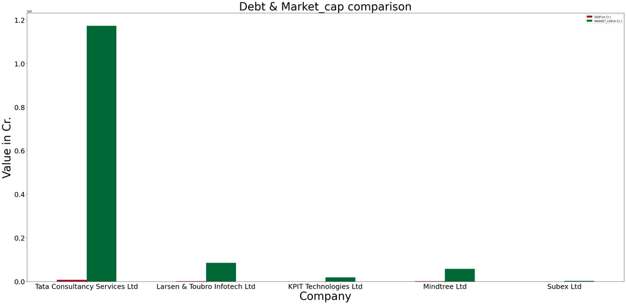

```python
IT_sector.plot(x="COMPANY", y=["DEBT(in Cr.)","MARKET_CAP(in Cr.)"], kind="bar", figsize=(39, 18),\
                 rot=0 , colormap='RdYlGn',fontsize=25 )
plt.xlabel('Company',size=40)
plt.ylabel('Value in Cr.',size=40)
plt.title('Debt & Market_cap comparison',size=40)
```

## 8.2 CAGR check

```python
IT_sector[(IT_sector['CAGR_5yr(in %)']>20)& (IT_sector['CAGR_10yr(in %)']>20)]
```

|  | COMPANY | NSE_CODE | BSE_CODE | SECTOR | MARKET_CAP(in Cr.) | CURRENT_PRICE | DOWN_FROM_52w_HIGH(in %) | UP_FROM_52w_LOW(in %) | DEBT(in Cr.) | DIV_YIELD(in %) | BOOK_VALUE | PROMOTER_HOLDING(in %) | HOLDING_PLEDGED(in %) | SALES(in %) | SALES_GROWTH_5yrs(in %) | PROFIT(in %) | PROFIT_GROWTH_5yrs(in %) | ROCE(in %) | ROCE_5yr_AVG(in %) | ROE(in %) | ROE_5yr_AVG(in %) | PE_RATIO | PE_RATIO_5yr_AVG | CAGR_5yr(in %) | CAGR_10yr(in %) | EPS | ASSET_TURNOVER | QUICK_RATIO | DEBT_EQUITY_RATIO |
| --- | --- | --- | --- | --- | --- | --- | --- | --- | --- | --- | --- | --- | --- | --- | --- | --- | --- | --- | --- | --- | --- | --- | --- | --- | --- | --- | --- | --- | --- |
| 48 | Mindtree Ltd | MINDTREE | 532819 | IT - Software | 57401 | 3480.0 | 31.2 | 31.4 | 613.0 | 1.06 | 344.0 | 61.0 | 0.0 | 35.0 | 15.0 | 36.4 | 31.6 | 41.5 | 33.4 | 33.8 | 26.9 | 30.4 | 21.6 | 47.8 | 35.0 | 115.0 | 1.45 | 2.96 | 0.11 |

As, we are getting **Mindtree Ltd** from "IT- Sector" as per our all criteria and from "Telecomm-Service" sector **Tata Communications Ltd**. So, will do a comparison in these both stocks.

# 9. Stock comparison

```python
selected_stocks = df[(df['NSE_CODE']=='MINDTREE') | (df['NSE_CODE']=='TATACOMM')]
selected_stocks
```

|  | COMPANY | NSE_CODE | BSE_CODE | SECTOR | MARKET_CAP(in Cr.) | CURRENT_PRICE | DOWN_FROM_52w_HIGH(in %) | UP_FROM_52w_LOW(in %) | DEBT(in Cr.) | DIV_YIELD(in %) | BOOK_VALUE | PROMOTER_HOLDING(in %) | HOLDING_PLEDGED(in %) | SALES(in %) | SALES_GROWTH_5yrs(in %) | PROFIT(in %) | PROFIT_GROWTH_5yrs(in %) | ROCE(in %) | ROCE_5yr_AVG(in %) | ROE(in %) | ROE_5yr_AVG(in %) | PE_RATIO | PE_RATIO_5yr_AVG | CAGR_5yr(in %) | CAGR_10yr(in %) | EPS | ASSET_TURNOVER | QUICK_RATIO | DEBT_EQUITY_RATIO |
| --- | --- | --- | --- | --- | --- | --- | --- | --- | --- | --- | --- | --- | --- | --- | --- | --- | --- | --- | --- | --- | --- | --- | --- | --- | --- | --- | --- | --- | --- |
| 29 | Tata Communications Ltd | TATACOMM | 500483 | Telecomm-Service | 37453 | 1314.0 | 17.4 | 53.5 | 8840.0 | 1.58 | 31.8 | 58.9 | 4.96 | 3.72 | -1.04 | 34.2 | -6.74 | 21.8 | 13.2 | 282.0 | 0.0 | 21.1 | 16.7 | 24.6 | 24.4 | 64.4 | 0.82 | 0.61 | 9.74 |
| 48 | Mindtree Ltd | MINDTREE | 532819 | IT - Software | 57401 | 3480.0 | 31.2 | 31.4 | 613.0 | 1.06 | 344.0 | 61.0 | 0.00 | 35.00 | 15.00 | 36.4 | 31.60 | 41.5 | 33.4 | 33.8 | 26.9 | 30.4 | 21.6 | 47.8 | 35.0 | 115.0 | 1.45 | 2.96 | 0.11 |

## 9.1 Profit growth check

- So for selecting a stock for a investor profit growths matter alot because if the company earns then the stock will run

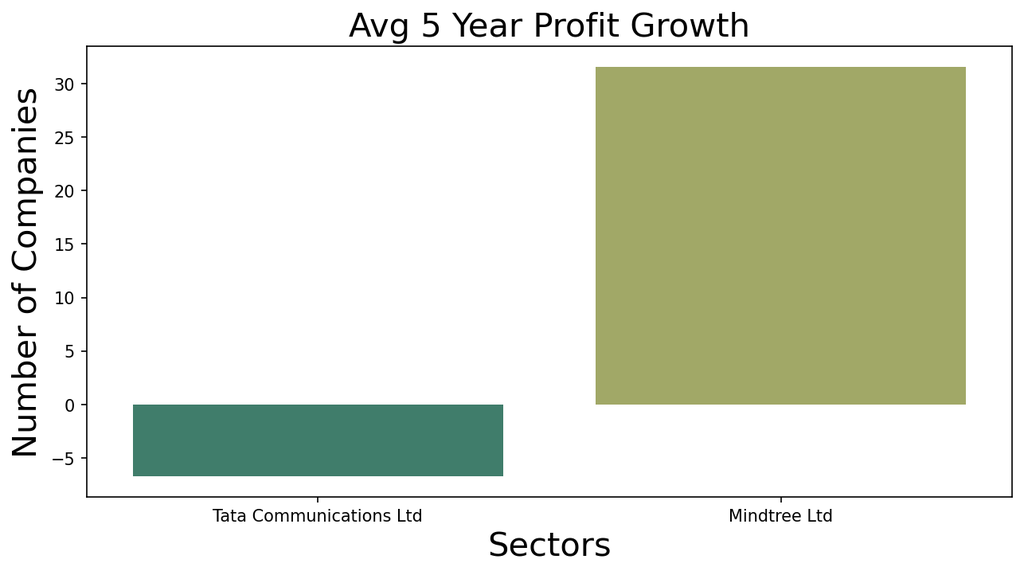

```python
plt.figure(figsize=(10,5), dpi=150)
plt.xticks(rotation=0)
plt.title('Avg 5 Year Profit Growth',size=20)
chart_A=sns.barplot(data=selected_stocks, x='COMPANY', y='PROFIT_GROWTH_5yrs(in %)',palette='gist_earth')
plt.xlabel('Sectors',size=20)
plt.ylabel('Number of Companies',size=20)
```

- In above analysis we found that the Avg profit growth of TCL is not up to mark. So, for final conclusion will check the Quick ratio of both the companies.

## 9.2 Quick ratio check

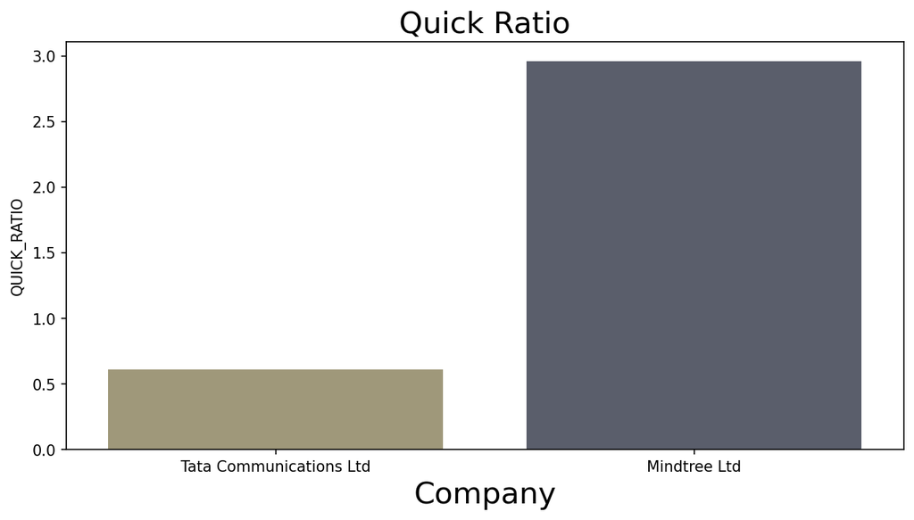

```python
plt.figure(figsize=(10,5), dpi=150)
plt.xticks(rotation=0)
plt.title('Quick Ratio',size=20)
chart_A=sns.barplot(data=selected_stocks, x='COMPANY', y='QUICK_RATIO',palette='cividis_r')
plt.xlabel('Company',size=20)
```

So, we can see that the Mind Tree Ltd. holds a great quick ratio(repayment of loans capability) which shows that we can keep a track on this company

Thank You